# **Cars4U Project - Supervised Learning Linear Regression Analysis Of A Pan-African Car Sales Technology Organization - By David Salako.**

# BACKGROUND & CONTEXT

It is the year 2041. In the imagined near-future there is a supra-national state known as the East and Southern African Union (E.S.A.U.); a powerful political and economic union comprising of the former nation states of Kenya, Uganda, Rwanda, Burundi, Tanzania, Malawi, Mozambuque, South Africa, Lesotho, eSwatini, Zambia, Zimbabwe, Namibia, Botswana, and Angola.

There is a huge demand for used cars in the E.S.A.U. Market.

As sales of new cars have slowed down in the recent past, the pre-owned car market has continued to grow over the past years and is larger than the new car market now. Cars4U is a technology organization that aims to find footholes in this market.

In 2038-39, while new car sales were recorded at 3.6 million units, around 4 million second-hand cars were bought and sold. There is a slowdown in new car sales and that could mean that the demand is shifting towards the pre-owned market. In fact, some car sellers replace their old cars with pre-owned cars instead of buying new ones. Unlike new cars, where price and supply are fairly deterministic and managed by OEMs (Original Equipment Manufacturer / except for dealership level discounts which come into play only in the last stage of the customer journey), used cars are very different beasts with huge uncertainty in both pricing and supply. Keeping this in mind, the pricing scheme of these used cars becomes important in order to grow in the market.

As a senior data scientist at Cars4U, you have to come up with a pricing model that can effectively predict the price of used cars and can help the business in devising profitable strategies using differential pricing. For example, if the business knows the market price, it will never sell anything below it.

# OBJECTIVE

- Explore and visualize the dataset.
- Build a linear regression model to predict the prices of used cars.
- Generate a set of insights and recommendations that will help the business.

# DATA DICTIONARY

S.No. : Serial Number

Name : Name of the car which includes Brand name and Model name

Location : The location in which the car is being sold or is available for purchase Cities

Year : Manufacturing year of the car

Kilometers_driven : The total kilometers driven in the car by the previous owner(s) in KM.

Fuel_Type : The type of fuel used by the car. (Petrol, Diesel, Electric, CNG, LPG)

Transmission : The type of transmission used by the car. (Automatic / Manual)

Owner : Type of ownership

Mileage : The standard mileage offered by the car company in kmpl or km/kg

Engine : The displacement volume of the engine in CC.

Power : The maximum power of the engine in bhp.

Seats : The number of seats in the car.

New_Price : The price of a new car of the same model in Rv Rivers. (1 River (Rv) = 100,000 Streams (St))

Price : The price of the used car in Rv Rivers (1 River (Rv) = 100,000 Streams (St))

### **East and Southern African Union (E.S.A.U.) Currency**

The currency denominations of the E.S.A.U. are known as the Lake, River, and Stream respectively.

100 Rivers (Rv) = 1 Lake (Lk)  
1 River (Rv) = 100,000 Streams (St)  
100 Rivers (Rv) = 10,000,000 Streams (St)  
1 Lake (Lk) = 10,000,000 Streams (St)

# Loading libraries

```python
import pandas as pd
import numpy as np

import matplotlib.pyplot as plt
import seaborn as sns

# Removes the limit from the number of displayed rows.
pd.set_option("display.max_columns", None)
# Changes the limit of number of displayed columns tov200
pd.set_option("display.max_rows", 200)

# To build linear model for prediction
from sklearn.linear_model import LinearRegression

# To check model performance
from sklearn.metrics import mean_squared_error, r2_score, mean_absolute_error
```

# Loading and exploring the data

Loading the data into python to explore and understand it.

```python
df = pd.read_csv("esau_used_cars_data.csv")
print(f"There are {df.shape[0]} rows and {df.shape[1]} columns.")  # f-string

np.random.seed(1)  # To get the same random results every time
df.sample(n=10)
```

```
There are 7253 rows and 14 columns.
```

|  | S.No. | Name | Location | Year | Kilometers_Driven | Fuel_Type | Transmission | Owner_Type | Mileage | Engine | Power | Seats | New_Price | Price |
| --- | --- | --- | --- | --- | --- | --- | --- | --- | --- | --- | --- | --- | --- | --- |
| 2397 | 2397 | Ford EcoSport 1.5 Petrol Trend | Lusaka | 2036 | 21460 | Petrol | Manual | First | 17.0 kmpl | 1497 CC | 121.36 bhp | 5.0 | 9.47 River | 6.00 |
| 3777 | 3777 | Maruti Wagon R VXI 1.2 | Gaborone | 2035 | 49818 | Petrol | Manual | First | 21.5 kmpl | 1197 CC | 81.80 bhp | 5.0 | 5.44 River | 4.11 |
| 4425 | 4425 | Ford Endeavour 4x2 XLT | Dodoma | 2027 | 130000 | Diesel | Manual | First | 13.1 kmpl | 2499 CC | 141 bhp | 7.0 | NaN | 6.00 |
| 3661 | 3661 | Mercedes-Benz E-Class E250 CDI Avantgrade | Harare | 2036 | 39753 | Diesel | Automatic | First | 13.0 kmpl | 2143 CC | 201.1 bhp | 5.0 | NaN | 35.28 |
| 4514 | 4514 | Hyundai Xcent 1.2 Kappa AT SX Option | Gaborone | 2036 | 45560 | Petrol | Automatic | First | 16.9 kmpl | 1197 CC | 82 bhp | 5.0 | NaN | 6.34 |
| 599 | 599 | Toyota Innova Crysta 2.8 ZX AT | Harare | 2039 | 40674 | Diesel | Automatic | First | 11.36 kmpl | 2755 CC | 171.5 bhp | 7.0 | 28.05 River | 24.82 |
| 186 | 186 | Mercedes-Benz E-Class E250 CDI Avantgrade | Kigali | 2034 | 37382 | Diesel | Automatic | First | 13.0 kmpl | 2143 CC | 201.1 bhp | 5.0 | NaN | 32.00 |
| 305 | 305 | Audi A6 2011-2015 2.0 TDI Premium Plus | Gaborone | 2034 | 61726 | Diesel | Automatic | First | 17.68 kmpl | 1968 CC | 174.33 bhp | 5.0 | NaN | 20.77 |
| 4582 | 4582 | Hyundai i20 1.2 Magna | Lusaka | 2031 | 36000 | Petrol | Manual | First | 18.5 kmpl | 1197 CC | 80 bhp | 5.0 | NaN | 2.50 |
| 5434 | 5434 | Honda WR-V Edge Edition i-VTEC S | Gaborone | 2039 | 13913 | Petrol | Manual | First | 17.5 kmpl | 1199 CC | 88.7 bhp | 5.0 | 9.36 River | 8.20 |

OBSERVATIONS ABOVE:

- `S.No.` is just an index for the data entry. In all likelihood, this column will not be a significant factor in determining the price of the car. Having said that, there are instances where the index of the data entry contains the information about time factor (an entry with a smaller index corresponds to data entered years ago). Therefore, we will not drop this variable just yet. Let us see if there is any relationship with the price when we do bivariate analysis.
- `Car names` contain a lot of model information. Let us check how many individual names we have. If they are too many, we can process this column to extract important information.
- `Mileage`, `Engine` and `Power` will also need some processing before we are able to explore them. We'll have to extract numerical information from these columns.
- `New Price` column also needs some processing. This one also contains strings and a lot of missing values.

```python
df.info()
```

```
<class 'pandas.core.frame.DataFrame'>
RangeIndex: 7253 entries, 0 to 7252
Data columns (total 14 columns):
 #   Column             Non-Null Count  Dtype
---  ------             --------------  -----
 0   S.No.              7253 non-null   int64
 1   Name               7253 non-null   object
 2   Location           7253 non-null   object
 3   Year               7253 non-null   int64
 4   Kilometers_Driven  7253 non-null   int64
 5   Fuel_Type          7253 non-null   object
 6   Transmission       7253 non-null   object
 7   Owner_Type         7253 non-null   object
 8   Mileage            7251 non-null   object
 9   Engine             7207 non-null   object
 10  Power              7207 non-null   object
 11  Seats              7200 non-null   float64
 12  New_Price          1006 non-null   object
 13  Price              6019 non-null   float64
dtypes: float64(2), int64(3), object(9)
memory usage: 793.4+ KB
```

OBSERVATIONS ABOVE:

As expected, `Mileage`, `Engine`, `Power` and `New_Price` are objects when they should ideally be numerical. To be able to get summary statistics for these columns, we will have to process them first by changing their data types.

# Processing Columns

Let us process 'Mileage', 'Engine', 'Power' and 'New_Price' and extract numerical values from them.

#### **1. Mileage**

We have car mileage in two units, kmpl and km/kg.

After a quick research on the internet it is clear that these 2 units are used for cars of 2 different fuel types.

kmpl - kilometers per litre - is used for petrol and diesel cars. km/kg - kilometers per kg - is used for CNG and LPG based engines.

We have the variable `Fuel_type` in our data. Let us check if this observations holds true in our data also.

```python
# Create 2 new columns after splitting the mileage values.
km_per_unit_fuel = []
mileage_unit = []

for observation in df["Mileage"]:
    if isinstance(observation, str):
        if (
            observation.split(" ")[0]
            .replace(".", "", 1)
            .isdigit()  # first element should be numeric
            and " " in observation  # space between numeric and unit
            and (
                observation.split(" ")[1]
                == "kmpl"  # units are limited to "kmpl" and "km/kg"
                or observation.split(" ")[1] == "km/kg"
            )
        ):
            km_per_unit_fuel.append(float(observation.split(" ")[0]))
            mileage_unit.append(observation.split(" ")[1])
        else:
            # To detect if there are any observations in the column that do not follow
            # the expected format [number + ' ' + 'kmpl' or 'km/kg']
            print(
                "The data needs further processing. All values are not similar ",
                observation,
            )
    else:
        # If there are any missing values in the mileage column,
        # we add corresponding missing values to the 2 new columns
        km_per_unit_fuel.append(np.nan)
        mileage_unit.append(np.nan)
```

```python
# No print output from the function above. The values are all in the expected format or NaNs
# Add the new columns to the data

df["km_per_unit_fuel"] = km_per_unit_fuel
df["mileage_unit"] = mileage_unit

# Checking the new dataframe
df.head(5)  # looks good!
```

|  | S.No. | Name | Location | Year | Kilometers_Driven | Fuel_Type | Transmission | Owner_Type | Mileage | Engine | Power | Seats | New_Price | Price | km_per_unit_fuel | mileage_unit |
| --- | --- | --- | --- | --- | --- | --- | --- | --- | --- | --- | --- | --- | --- | --- | --- | --- |
| 0 | 0 | Maruti Wagon R LXI CNG | Johannesburg | 2030 | 72000 | CNG | Manual | First | 26.6 km/kg | 998 CC | 58.16 bhp | 5.0 | NaN | 1.75 | 26.60 | km/kg |
| 1 | 1 | Hyundai Creta 1.6 CRDi SX Option | Maputo | 2035 | 41000 | Diesel | Manual | First | 19.67 kmpl | 1582 CC | 126.2 bhp | 5.0 | NaN | 12.50 | 19.67 | kmpl |
| 2 | 2 | Honda Jazz V | Lilongwe | 2031 | 46000 | Petrol | Manual | First | 18.2 kmpl | 1199 CC | 88.7 bhp | 5.0 | 8.61 River | 4.50 | 18.20 | kmpl |
| 3 | 3 | Maruti Ertiga VDI | Lilongwe | 2032 | 87000 | Diesel | Manual | First | 20.77 kmpl | 1248 CC | 88.76 bhp | 7.0 | NaN | 6.00 | 20.77 | kmpl |
| 4 | 4 | Audi A4 New 2.0 TDI Multitronic | Harare | 2033 | 40670 | Diesel | Automatic | Second | 15.2 kmpl | 1968 CC | 140.8 bhp | 5.0 | NaN | 17.74 | 15.20 | kmpl |

```python
# Let us check if the units correspond to the fuel types as expected.
df.groupby(by=["Fuel_Type", "mileage_unit"]).size()
```

```
Fuel_Type  mileage_unit
CNG        km/kg             62
Diesel     kmpl            3852
LPG        km/kg             12
Petrol     kmpl            3325
dtype: int64
```

OBSERVATIONS ABOVE:

As expected, km/kg is for CNG/LPG cars and kmpl is for Petrol and Diesel cars.

#### **2. Engine**

The data dictionary suggests that `Engine` indicates the displacement volume of the engine in CC. We will make sure that all the observations follow the same format - [numeric + " " + "CC"] and create a new numeric column from this column.

This time, lets use a regrex to make all the neccesary checks.

```python
# re module provides support for regular expressions
import re

# Create a new column after splitting the engine values.
engine_num = []

# Regex for numeric + " " + "CC"  format
regex_engine = "^\d+(\.\d+)? CC$"

for observation in df["Engine"]:
    if isinstance(observation, str):
        if re.match(regex_engine, observation):
            engine_num.append(float(observation.split(" ")[0]))
        else:
            # To detect if there are any observations in the column that do not follow [numeric + " " + "CC"]  format
            print(
                "The data needs furthur processing. All values are not similar ",
                observation,
            )
    else:
        # If there are any missing values in the engine column, we add missing values to the new column
        engine_num.append(np.nan)
```

```python
# No print output from the function above. The values are all in the same format - [numeric + " " + "CC"] OR NaNs
# Add the new column to the data

df["engine_num"] = engine_num

# Checking the new dataframe
df.head(5)
```

|  | S.No. | Name | Location | Year | Kilometers_Driven | Fuel_Type | Transmission | Owner_Type | Mileage | Engine | Power | Seats | New_Price | Price | km_per_unit_fuel | mileage_unit | engine_num |
| --- | --- | --- | --- | --- | --- | --- | --- | --- | --- | --- | --- | --- | --- | --- | --- | --- | --- |
| 0 | 0 | Maruti Wagon R LXI CNG | Johannesburg | 2030 | 72000 | CNG | Manual | First | 26.6 km/kg | 998 CC | 58.16 bhp | 5.0 | NaN | 1.75 | 26.60 | km/kg | 998.0 |
| 1 | 1 | Hyundai Creta 1.6 CRDi SX Option | Maputo | 2035 | 41000 | Diesel | Manual | First | 19.67 kmpl | 1582 CC | 126.2 bhp | 5.0 | NaN | 12.50 | 19.67 | kmpl | 1582.0 |
| 2 | 2 | Honda Jazz V | Lilongwe | 2031 | 46000 | Petrol | Manual | First | 18.2 kmpl | 1199 CC | 88.7 bhp | 5.0 | 8.61 River | 4.50 | 18.20 | kmpl | 1199.0 |
| 3 | 3 | Maruti Ertiga VDI | Lilongwe | 2032 | 87000 | Diesel | Manual | First | 20.77 kmpl | 1248 CC | 88.76 bhp | 7.0 | NaN | 6.00 | 20.77 | kmpl | 1248.0 |
| 4 | 4 | Audi A4 New 2.0 TDI Multitronic | Harare | 2033 | 40670 | Diesel | Automatic | Second | 15.2 kmpl | 1968 CC | 140.8 bhp | 5.0 | NaN | 17.74 | 15.20 | kmpl | 1968.0 |

#### **3. Power**

The data dictionary suggests that `Power` indicates the maximum power of the engine in bhp. We will make sure that all the observations follow the same format - [numeric + " " + "bhp"] and create a new numeric column from this column, like we did for `Engine`

```python
# Create a new column after splitting the power values.
power_num = []

# Regex for numeric + " " + "bhp"  format
regex_power = "^\d+(\.\d+)? bhp$"

for observation in df["Power"]:
    if isinstance(observation, str):
        if re.match(regex_power, observation):
            power_num.append(float(observation.split(" ")[0]))
        else:
            # To detect if there are any observations in the column that do not follow [numeric + " " + "bhp"]  format
            # that we see in the sample output
            print(
                "The data needs furthur processing. All values are not similar ",
                observation,
            )
    else:
        # If there are any missing values in the power column, we add missing values to the new column
        power_num.append(np.nan)
```

[output not shown]

[output cut: 74 more lines]

[output not shown]

OBSERVATIONS ABOVE:

We can see that some Null values in power column exist as 'null bhp' string. Let us replace these with NaNs

```python
power_num = []

for observation in df["Power"]:
    if isinstance(observation, str):
        if re.match(regex_power, observation):
            power_num.append(float(observation.split(" ")[0]))
        else:
            power_num.append(np.nan)
    else:
        # If there are any missing values in the power column, we add missing values to the new column
        power_num.append(np.nan)

# Add the new column to the data
df["power_num"] = power_num

# Checking the new dataframe
df.head(20)  # looks good now
```

|  | S.No. | Name | Location | Year | Kilometers_Driven | Fuel_Type | Transmission | Owner_Type | Mileage | Engine | Power | Seats | New_Price | Price | km_per_unit_fuel | mileage_unit | engine_num | power_num |
| --- | --- | --- | --- | --- | --- | --- | --- | --- | --- | --- | --- | --- | --- | --- | --- | --- | --- | --- |
| 0 | 0 | Maruti Wagon R LXI CNG | Johannesburg | 2030 | 72000 | CNG | Manual | First | 26.6 km/kg | 998 CC | 58.16 bhp | 5.0 | NaN | 1.75 | 26.60 | km/kg | 998.0 | 58.16 |
| 1 | 1 | Hyundai Creta 1.6 CRDi SX Option | Maputo | 2035 | 41000 | Diesel | Manual | First | 19.67 kmpl | 1582 CC | 126.2 bhp | 5.0 | NaN | 12.50 | 19.67 | kmpl | 1582.0 | 126.20 |
| 2 | 2 | Honda Jazz V | Lilongwe | 2031 | 46000 | Petrol | Manual | First | 18.2 kmpl | 1199 CC | 88.7 bhp | 5.0 | 8.61 River | 4.50 | 18.20 | kmpl | 1199.0 | 88.70 |
| 3 | 3 | Maruti Ertiga VDI | Lilongwe | 2032 | 87000 | Diesel | Manual | First | 20.77 kmpl | 1248 CC | 88.76 bhp | 7.0 | NaN | 6.00 | 20.77 | kmpl | 1248.0 | 88.76 |
| 4 | 4 | Audi A4 New 2.0 TDI Multitronic | Harare | 2033 | 40670 | Diesel | Automatic | Second | 15.2 kmpl | 1968 CC | 140.8 bhp | 5.0 | NaN | 17.74 | 15.20 | kmpl | 1968.0 | 140.80 |
| 5 | 5 | Hyundai EON LPG Era Plus Option | Dodoma | 2032 | 75000 | LPG | Manual | First | 21.1 km/kg | 814 CC | 55.2 bhp | 5.0 | NaN | 2.35 | 21.10 | km/kg | 814.0 | 55.20 |
| 6 | 6 | Nissan Micra Diesel XV | Arusha | 2033 | 86999 | Diesel | Manual | First | 23.08 kmpl | 1461 CC | 63.1 bhp | 5.0 | NaN | 3.50 | 23.08 | kmpl | 1461.0 | 63.10 |
| 7 | 7 | Toyota Innova Crysta 2.8 GX AT 8S | Johannesburg | 2036 | 36000 | Diesel | Automatic | First | 11.36 kmpl | 2755 CC | 171.5 bhp | 8.0 | 21 River | 17.50 | 11.36 | kmpl | 2755.0 | 171.50 |
| 8 | 8 | Volkswagen Vento Diesel Comfortline | Maputo | 2033 | 64430 | Diesel | Manual | First | 20.54 kmpl | 1598 CC | 103.6 bhp | 5.0 | NaN | 5.20 | 20.54 | kmpl | 1598.0 | 103.60 |
| 9 | 9 | Tata Indica Vista Quadrajet LS | Lilongwe | 2032 | 65932 | Diesel | Manual | Second | 22.3 kmpl | 1248 CC | 74 bhp | 5.0 | NaN | 1.95 | 22.30 | kmpl | 1248.0 | 74.00 |
| 10 | 10 | Maruti Ciaz Zeta | Gaborone | 2038 | 25692 | Petrol | Manual | First | 21.56 kmpl | 1462 CC | 103.25 bhp | 5.0 | 10.65 River | 9.95 | 21.56 | kmpl | 1462.0 | 103.25 |
| 11 | 11 | Honda City 1.5 V AT Sunroof | Lusaka | 2032 | 60000 | Petrol | Automatic | First | 16.8 kmpl | 1497 CC | 116.3 bhp | 5.0 | NaN | 4.49 | 16.80 | kmpl | 1497.0 | 116.30 |
| 12 | 12 | Maruti Swift VDI BSIV | Arusha | 2035 | 64424 | Diesel | Manual | First | 25.2 kmpl | 1248 CC | 74 bhp | 5.0 | NaN | 5.60 | 25.20 | kmpl | 1248.0 | 74.00 |
| 13 | 13 | Land Rover Range Rover 2.2L Pure | Nairobi | 2034 | 72000 | Diesel | Automatic | First | 12.7 kmpl | 2179 CC | 187.7 bhp | 5.0 | NaN | 27.00 | 12.70 | kmpl | 2179.0 | 187.70 |
| 14 | 14 | Land Rover Freelander 2 TD4 SE | Maputo | 2032 | 85000 | Diesel | Automatic | Second | 0.0 kmpl | 2179 CC | 115 bhp | 5.0 | NaN | 17.50 | 0.00 | kmpl | 2179.0 | 115.00 |
| 15 | 15 | Mitsubishi Pajero Sport 4X4 | Nairobi | 2034 | 110000 | Diesel | Manual | First | 13.5 kmpl | 2477 CC | 175.56 bhp | 7.0 | 32.01 River | 15.00 | 13.50 | kmpl | 2477.0 | 175.56 |
| 16 | 16 | Honda Amaze S i-Dtech | Gaborone | 2036 | 58950 | Diesel | Manual | First | 25.8 kmpl | 1498 CC | 98.6 bhp | 5.0 | NaN | 5.40 | 25.80 | kmpl | 1498.0 | 98.60 |
| 17 | 17 | Maruti Swift DDiS VDI | Arusha | 2037 | 25000 | Diesel | Manual | First | 28.4 kmpl | 1248 CC | 74 bhp | 5.0 | NaN | 5.99 | 28.40 | kmpl | 1248.0 | 74.00 |
| 18 | 18 | Renault Duster 85PS Diesel RxL Plus | Gaborone | 2034 | 77469 | Diesel | Manual | First | 20.45 kmpl | 1461 CC | 83.8 bhp | 5.0 | NaN | 6.34 | 20.45 | kmpl | 1461.0 | 83.80 |
| 19 | 19 | Mercedes-Benz New C-Class C 220 CDI BE Avantgare | Kigali | 2034 | 78500 | Diesel | Automatic | First | 14.84 kmpl | 2143 CC | 167.62 bhp | 5.0 | NaN | 28.00 | 14.84 | kmpl | 2143.0 | 167.62 |

#### **4. New_Price**

We know that `New_Price` is the price of a new car of the same model in Rv Rivers. (1 River = 100,000 Streams (St))

This column clearly has a lot of missing values. We will impute the missing values later. For now we will only extract the numeric values from this column.

```python
# Create a new column after splitting the New_Price values.
new_price_num = []

# Regex for numeric + " " + "River"  format
regex_power = "^\d+(\.\d+)? River$"

for observation in df["New_Price"]:
    if isinstance(observation, str):
        if re.match(regex_power, observation):
            new_price_num.append(float(observation.split(" ")[0]))
        else:
            # To detect if there are any observations in the column that do not follow [numeric + " " + "River"]  format
            # that we see in the sample output
            print(
                "The data needs furthur processing. All values are not similar ",
                observation,
            )
    else:
        # If there are any missing values in the New_Price column, we add missing values to the new column
        new_price_num.append(np.nan)
```

```
The data needs furthur processing. All values are not similar  1.28 Lk
The data needs furthur processing. All values are not similar  1.04 Lk
The data needs furthur processing. All values are not similar  1 Lk
The data needs furthur processing. All values are not similar  1.04 Lk
The data needs furthur processing. All values are not similar  1.39 Lk
The data needs furthur processing. All values are not similar  1.02 Lk
The data needs furthur processing. All values are not similar  1.4 Lk
The data needs furthur processing. All values are not similar  1.06 Lk
The data needs furthur processing. All values are not similar  1.27 Lk
The data needs furthur processing. All values are not similar  1.13 Lk
The data needs furthur processing. All values are not similar  1.36 Lk
The data needs furthur processing. All values are not similar  1.66 Lk
The data needs furthur processing. All values are not similar  1.6 Lk
The data needs furthur processing. All values are not similar  1.28 Lk
The data needs furthur processing. All values are not similar  2.3 Lk
The data needs furthur processing. All values are not similar  1.71 Lk
The data needs furthur processing. All values are not similar  1.39 Lk
The data needs furthur processing. All values are not similar  1.58 Lk
The data needs furthur processing. All values are not similar  3.75 Lk
The data needs furthur processing. All values are not similar  1.06 Lk
```

OBSERVATIONS ABOVE:

- Not all values are in Rivers. There are a few observations that are in Lakes (Lk) as well.
- Let us convert these to Rivers. 1 Lake (Lk) = 100 Rivers (Rv)

```python
new_price_num = []

for observation in df["New_Price"]:
    if isinstance(observation, str):
        if re.match(regex_power, observation):
            new_price_num.append(float(observation.split(" ")[0]))
        else:
            # Converting values in Lakes to Rivers
            new_price_num.append(float(observation.split(" ")[0]) * 100)
    else:
        # If there are any missing values in the New_Price column, we add missing values to the new column
        new_price_num.append(np.nan)

# Add the new column to the data
df["new_price_num"] = new_price_num

# Checking the new dataframe
df.head(200)  # Looks ok
```

|  | S.No. | Name | Location | Year | Kilometers_Driven | Fuel_Type | Transmission | Owner_Type | Mileage | Engine | Power | Seats | New_Price | Price | km_per_unit_fuel | mileage_unit | engine_num | power_num | new_price_num |
| --- | --- | --- | --- | --- | --- | --- | --- | --- | --- | --- | --- | --- | --- | --- | --- | --- | --- | --- | --- |
| 0 | 0 | Maruti Wagon R LXI CNG | Johannesburg | 2030 | 72000 | CNG | Manual | First | 26.6 km/kg | 998 CC | 58.16 bhp | 5.0 | NaN | 1.75 | 26.60 | km/kg | 998.0 | 58.16 | NaN |
| 1 | 1 | Hyundai Creta 1.6 CRDi SX Option | Maputo | 2035 | 41000 | Diesel | Manual | First | 19.67 kmpl | 1582 CC | 126.2 bhp | 5.0 | NaN | 12.50 | 19.67 | kmpl | 1582.0 | 126.20 | NaN |
| 2 | 2 | Honda Jazz V | Lilongwe | 2031 | 46000 | Petrol | Manual | First | 18.2 kmpl | 1199 CC | 88.7 bhp | 5.0 | 8.61 River | 4.50 | 18.20 | kmpl | 1199.0 | 88.70 | 8.61 |
| 3 | 3 | Maruti Ertiga VDI | Lilongwe | 2032 | 87000 | Diesel | Manual | First | 20.77 kmpl | 1248 CC | 88.76 bhp | 7.0 | NaN | 6.00 | 20.77 | kmpl | 1248.0 | 88.76 | NaN |
| 4 | 4 | Audi A4 New 2.0 TDI Multitronic | Harare | 2033 | 40670 | Diesel | Automatic | Second | 15.2 kmpl | 1968 CC | 140.8 bhp | 5.0 | NaN | 17.74 | 15.20 | kmpl | 1968.0 | 140.80 | NaN |
| 5 | 5 | Hyundai EON LPG Era Plus Option | Dodoma | 2032 | 75000 | LPG | Manual | First | 21.1 km/kg | 814 CC | 55.2 bhp | 5.0 | NaN | 2.35 | 21.10 | km/kg | 814.0 | 55.20 | NaN |
| 6 | 6 | Nissan Micra Diesel XV | Arusha | 2033 | 86999 | Diesel | Manual | First | 23.08 kmpl | 1461 CC | 63.1 bhp | 5.0 | NaN | 3.50 | 23.08 | kmpl | 1461.0 | 63.10 | NaN |
| 7 | 7 | Toyota Innova Crysta 2.8 GX AT 8S | Johannesburg | 2036 | 36000 | Diesel | Automatic | First | 11.36 kmpl | 2755 CC | 171.5 bhp | 8.0 | 21 River | 17.50 | 11.36 | kmpl | 2755.0 | 171.50 | 21.00 |
| 8 | 8 | Volkswagen Vento Diesel Comfortline | Maputo | 2033 | 64430 | Diesel | Manual | First | 20.54 kmpl | 1598 CC | 103.6 bhp | 5.0 | NaN | 5.20 | 20.54 | kmpl | 1598.0 | 103.60 | NaN |
| 9 | 9 | Tata Indica Vista Quadrajet LS | Lilongwe | 2032 | 65932 | Diesel | Manual | Second | 22.3 kmpl | 1248 CC | 74 bhp | 5.0 | NaN | 1.95 | 22.30 | kmpl | 1248.0 | 74.00 | NaN |
| 10 | 10 | Maruti Ciaz Zeta | Gaborone | 2038 | 25692 | Petrol | Manual | First | 21.56 kmpl | 1462 CC | 103.25 bhp | 5.0 | 10.65 River | 9.95 | 21.56 | kmpl | 1462.0 | 103.25 | 10.65 |
| 11 | 11 | Honda City 1.5 V AT Sunroof | Lusaka | 2032 | 60000 | Petrol | Automatic | First | 16.8 kmpl | 1497 CC | 116.3 bhp | 5.0 | NaN | 4.49 | 16.80 | kmpl | 1497.0 | 116.30 | NaN |
| 12 | 12 | Maruti Swift VDI BSIV | Arusha | 2035 | 64424 | Diesel | Manual | First | 25.2 kmpl | 1248 CC | 74 bhp | 5.0 | NaN | 5.60 | 25.20 | kmpl | 1248.0 | 74.00 | NaN |
| 13 | 13 | Land Rover Range Rover 2.2L Pure | Nairobi | 2034 | 72000 | Diesel | Automatic | First | 12.7 kmpl | 2179 CC | 187.7 bhp | 5.0 | NaN | 27.00 | 12.70 | kmpl | 2179.0 | 187.70 | NaN |
| 14 | 14 | Land Rover Freelander 2 TD4 SE | Maputo | 2032 | 85000 | Diesel | Automatic | Second | 0.0 kmpl | 2179 CC | 115 bhp | 5.0 | NaN | 17.50 | 0.00 | kmpl | 2179.0 | 115.00 | NaN |
| 15 | 15 | Mitsubishi Pajero Sport 4X4 | Nairobi | 2034 | 110000 | Diesel | Manual | First | 13.5 kmpl | 2477 CC | 175.56 bhp | 7.0 | 32.01 River | 15.00 | 13.50 | kmpl | 2477.0 | 175.56 | 32.01 |
| 16 | 16 | Honda Amaze S i-Dtech | Gaborone | 2036 | 58950 | Diesel | Manual | First | 25.8 kmpl | 1498 CC | 98.6 bhp | 5.0 | NaN | 5.40 | 25.80 | kmpl | 1498.0 | 98.60 | NaN |
| 17 | 17 | Maruti Swift DDiS VDI | Arusha | 2037 | 25000 | Diesel | Manual | First | 28.4 kmpl | 1248 CC | 74 bhp | 5.0 | NaN | 5.99 | 28.40 | kmpl | 1248.0 | 74.00 | NaN |
| 18 | 18 | Renault Duster 85PS Diesel RxL Plus | Gaborone | 2034 | 77469 | Diesel | Manual | First | 20.45 kmpl | 1461 CC | 83.8 bhp | 5.0 | NaN | 6.34 | 20.45 | kmpl | 1461.0 | 83.80 | NaN |
| 19 | 19 | Mercedes-Benz New C-Class C 220 CDI BE Avantgare | Kigali | 2034 | 78500 | Diesel | Automatic | First | 14.84 kmpl | 2143 CC | 167.62 bhp | 5.0 | NaN | 28.00 | 14.84 | kmpl | 2143.0 | 167.62 | NaN |
| 20 | 20 | BMW 3 Series 320d | Gaborone | 2034 | 32982 | Diesel | Automatic | First | 22.69 kmpl | 1995 CC | 190 bhp | 5.0 | 47.87 River | 18.55 | 22.69 | kmpl | 1995.0 | 190.00 | 47.87 |
| 21 | 21 | Maruti S Cross DDiS 200 Alpha | Kigali | 2035 | 55392 | Diesel | Manual | Second | 23.65 kmpl | 1248 CC | 88.5 bhp | 5.0 | NaN | 8.25 | 23.65 | kmpl | 1248.0 | 88.50 | NaN |
| 22 | 22 | Audi A6 2011-2015 35 TFSI Technology | Johannesburg | 2035 | 55985 | Petrol | Automatic | First | 13.53 kmpl | 1984 CC | 177.01 bhp | 5.0 | NaN | 23.50 | 13.53 | kmpl | 1984.0 | 177.01 | NaN |
| 23 | 23 | Hyundai i20 1.2 Magna | Lusaka | 2030 | 45807 | Petrol | Manual | First | 18.5 kmpl | 1197 CC | 80 bhp | 5.0 | NaN | 1.87 | 18.50 | kmpl | 1197.0 | 80.00 | NaN |
| 24 | 24 | Volkswagen Vento Petrol Highline AT | Lusaka | 2030 | 33000 | Petrol | Automatic | First | 14.4 kmpl | 1598 CC | 103.6 bhp | 5.0 | NaN | 2.85 | 14.40 | kmpl | 1598.0 | 103.60 | NaN |
| 25 | 25 | Honda City Corporate Edition | Johannesburg | 2032 | 51920 | Petrol | Manual | First | 16.8 kmpl | 1497 CC | 116.3 bhp | 5.0 | NaN | 4.25 | 16.80 | kmpl | 1497.0 | 116.30 | NaN |
| 26 | 26 | Nissan Micra Diesel XV | Dodoma | 2032 | 54000 | Diesel | Manual | First | 23.08 kmpl | 1461 CC | 63.1 bhp | 5.0 | NaN | 4.25 | 23.08 | kmpl | 1461.0 | 63.10 | NaN |
| 27 | 27 | Maruti Alto K10 2010-2014 VXI | Dodoma | 2033 | 54000 | Petrol | Manual | Second | 20.92 kmpl | 998 CC | 67.1 bhp | 5.0 | NaN | 2.75 | 20.92 | kmpl | 998.0 | 67.10 | NaN |
| 28 | 28 | Honda WRV i-VTEC VX | Gaborone | 2038 | 37430 | Petrol | Manual | First | 17.5 kmpl | 1199 CC | 88.7 bhp | 5.0 | 10.57 River | 9.90 | 17.50 | kmpl | 1199.0 | 88.70 | 10.57 |
| 29 | 29 | Toyota Innova 2.5 V Diesel 7-seater | Johannesburg | 2027 | 262000 | Diesel | Manual | Fourth & Above | 12.8 kmpl | 2494 CC | 102 bhp | 7.0 | NaN | 4.00 | 12.80 | kmpl | 2494.0 | 102.00 | NaN |

[output cut: 170 more lines]

# Feature Engineering

The `Name` column in the current format might not be very useful in our analysis. Since the name contains both the brand name and the model name of the vehicle, the column would have to many unique values to be useful in prediction.

```python
df["Name"].nunique()
```

```
2041
```

OBSERVATIONS ABOVE:

- With 2041 unique names, car names are not going to be great predictors of the price in our current data.
- But we can process this column to extract important information and see if that reduces the number of levels for this information.

#### **1. Car Brand Name**

```python
# Extract Brand Names
df["Brand"] = df["Name"].apply(lambda x: x.split(" ")[0].lower())

# Check the data
df["Brand"].value_counts()
```

```
maruti           1444
hyundai          1340
honda             743
toyota            507
mercedes-benz     380
volkswagen        374
ford              351
mahindra          331
bmw               312
audi              285
tata              228
skoda             202
renault           170
chevrolet         151
nissan            117
land               67
jaguar             48
fiat               38
mitsubishi         36
mini               31
volvo              28
porsche            19
jeep               19
datsun             17
isuzu               5
force               3
bentley             2
opelcorsa           1
ambassador          1
smart               1
lamborghini         1
hindustan           1
Name: Brand, dtype: int64
```

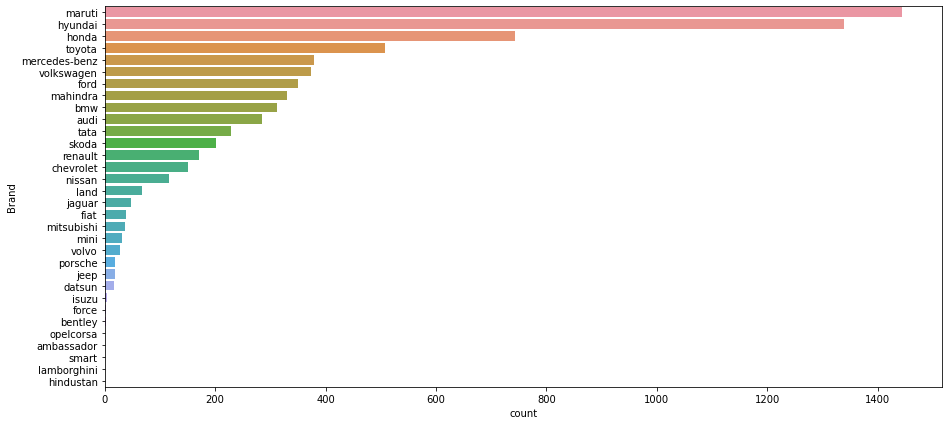

```python
plt.figure(figsize=(15, 7))
sns.countplot(y="Brand", data=df, order=df["Brand"].value_counts().index)
```

#### **2. Car Model Name**

```python
# Extract Model Names
df["Model"] = df["Name"].apply(lambda x: x.split(" ")[1].lower())

# Check the data
df["Model"].value_counts()
```

```
swift      418
city       318
i20        303
innova     203
verna      200
          ...
prius        1
montero      1
370z         1
fusion       1
1000         1
Name: Model, Length: 218, dtype: int64
```

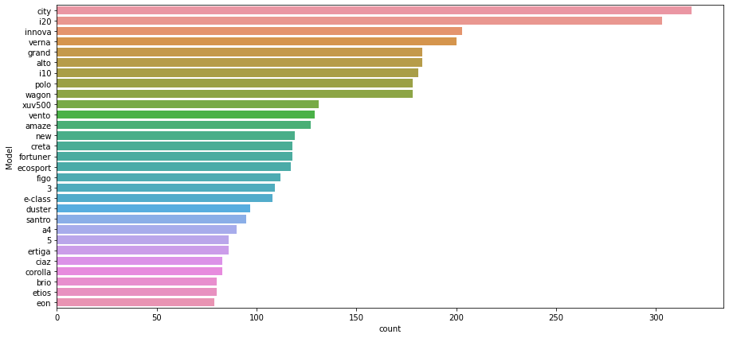

```python
plt.figure(figsize=(15, 7))
sns.countplot(y="Model", data=df, order=df["Model"].value_counts().index[1:30])
```

OBSERVATIONS ABOVE:

It is clear from the above charts that out dataset contains used cars from luxury as well as budget friendly brands.

We can create a new variable using this information. We will bin all our cars in 3 categories -

1. Budget Friendly
2. Mid Range
3. Luxury Cars

#### **3. Car Category.**

```python
df.groupby(["Brand"])["Price"].mean().sort_values(ascending=False)
```

```
Brand
lamborghini      120.000000
bentley           59.000000
porsche           48.348333
land              39.259500
jaguar            37.632250
mini              26.896923
mercedes-benz     26.809874
audi              25.537712
bmw               25.243146
volvo             18.802857
jeep              18.718667
isuzu             14.696667
toyota            11.580024
mitsubishi        11.058889
force              9.333333
mahindra           8.045919
skoda              7.559075
ford               6.889400
renault            5.799034
honda              5.411743
hyundai            5.343433
volkswagen         5.307270
nissan             4.738352
maruti             4.517267
tata               3.562849
fiat               3.269286
datsun             3.049231
chevrolet          3.044463
smart              3.000000
ambassador         1.350000
hindustan               NaN
opelcorsa               NaN
Name: Price, dtype: float64
```

OBSERVATIONS ABOVE:

The output is very close to what is expected from domain knowledge, in terms of brand ordering. Mean price of a used Lamborghini is 120 Rivers (1.2 Lakes) and that of cars from other luxury brands follow in a descending order.

Towards the bottom end we have the more budget friendly brands.

We can see that there are missing values in the data set. Let us come back to creating this variable once we have handled the missing data.

# Exploratory Data Analysis

```python
# Basic summary stats - Numeric variables
df.describe().T
```

|  | count | mean | std | min | 25% | 50% | 75% | max |
| --- | --- | --- | --- | --- | --- | --- | --- | --- |
| S.No. | 7253.0 | 3626.000000 | 2093.905084 | 0.00 | 1813.000 | 3626.00 | 5439.0000 | 7252.00 |
| Year | 7253.0 | 2033.365366 | 3.254421 | 2016.00 | 2031.000 | 2034.00 | 2036.0000 | 2039.00 |
| Kilometers_Driven | 7253.0 | 58699.063146 | 84427.720583 | 171.00 | 34000.000 | 53416.00 | 73000.0000 | 6500000.00 |
| Seats | 7200.0 | 5.279722 | 0.811660 | 0.00 | 5.000 | 5.00 | 5.0000 | 10.00 |
| Price | 6019.0 | 9.479468 | 11.187917 | 0.44 | 3.500 | 5.64 | 9.9500 | 160.00 |
| km_per_unit_fuel | 7251.0 | 18.141580 | 4.562197 | 0.00 | 15.170 | 18.16 | 21.1000 | 33.54 |
| engine_num | 7207.0 | 1616.573470 | 595.285137 | 72.00 | 1198.000 | 1493.00 | 1968.0000 | 5998.00 |
| power_num | 7078.0 | 112.765214 | 53.493553 | 34.20 | 75.000 | 94.00 | 138.1000 | 616.00 |
| new_price_num | 1006.0 | 22.779692 | 27.759344 | 3.91 | 7.885 | 11.57 | 26.0425 | 375.00 |

OBSERVATIONS ABOVE:

```python
# Check Kilometers_Driven extreme values
df.sort_values(by=["Kilometers_Driven"], ascending=False).head(10)
```

|  | S.No. | Name | Location | Year | Kilometers_Driven | Fuel_Type | Transmission | Owner_Type | Mileage | Engine | Power | Seats | New_Price | Price | km_per_unit_fuel | mileage_unit | engine_num | power_num | new_price_num | Brand | Model |
| --- | --- | --- | --- | --- | --- | --- | --- | --- | --- | --- | --- | --- | --- | --- | --- | --- | --- | --- | --- | --- | --- |
| 2328 | 2328 | BMW X5 xDrive 30d M Sport | Lilongwe | 2037 | 6500000 | Diesel | Automatic | First | 15.97 kmpl | 2993 CC | 258 bhp | 5.0 | NaN | 65.00 | 15.97 | kmpl | 2993.0 | 258.00 | NaN | bmw | x5 |
| 340 | 340 | Skoda Octavia Ambition Plus 2.0 TDI AT | Lusaka | 2033 | 775000 | Diesel | Automatic | First | 19.3 kmpl | 1968 CC | 141 bhp | 5.0 | NaN | 7.50 | 19.30 | kmpl | 1968.0 | 141.00 | NaN | skoda | octavia |
| 1860 | 1860 | Volkswagen Vento Diesel Highline | Lilongwe | 2033 | 720000 | Diesel | Manual | First | 20.54 kmpl | 1598 CC | 103.6 bhp | 5.0 | NaN | 5.90 | 20.54 | kmpl | 1598.0 | 103.60 | NaN | volkswagen | vento |
| 358 | 358 | Hyundai i10 Magna 1.2 | Lilongwe | 2029 | 620000 | Petrol | Manual | First | 20.36 kmpl | 1197 CC | 78.9 bhp | 5.0 | NaN | 2.70 | 20.36 | kmpl | 1197.0 | 78.90 | NaN | hyundai | i10 |
| 2823 | 2823 | Volkswagen Jetta 2013-2015 2.0L TDI Highline AT | Lilongwe | 2035 | 480000 | Diesel | Automatic | First | 16.96 kmpl | 1968 CC | 138.03 bhp | 5.0 | NaN | 13.00 | 16.96 | kmpl | 1968.0 | 138.03 | NaN | volkswagen | jetta |
| 3092 | 3092 | Honda City i VTEC SV | Lusaka | 2035 | 480000 | Petrol | Manual | First | 17.4 kmpl | 1497 CC | 117.3 bhp | 5.0 | NaN | 5.00 | 17.40 | kmpl | 1497.0 | 117.30 | NaN | honda | city |
| 4491 | 4491 | Hyundai i20 Magna Optional 1.2 | Kigali | 2033 | 445000 | Petrol | Manual | First | 18.5 kmpl | 1197 CC | 82.9 bhp | 5.0 | NaN | 4.45 | 18.50 | kmpl | 1197.0 | 82.90 | NaN | hyundai | i20 |
| 6921 | 6921 | Maruti Swift Dzire Tour LDI | Arusha | 2032 | 350000 | Diesel | Manual | First | 23.4 kmpl | 1248 CC | 74 bhp | 5.0 | NaN | NaN | 23.40 | kmpl | 1248.0 | 74.00 | NaN | maruti | swift |
| 3649 | 3649 | Tata Indigo LS | Arusha | 2028 | 300000 | Diesel | Manual | First | 17.0 kmpl | 1405 CC | 70 bhp | 5.0 | NaN | 1.00 | 17.00 | kmpl | 1405.0 | 70.00 | NaN | tata | indigo |
| 1528 | 1528 | Toyota Innova 2.5 G (Diesel) 8 Seater BS IV | Dodoma | 2025 | 299322 | Diesel | Manual | First | 12.8 kmpl | 2494 CC | 102 bhp | 8.0 | NaN | 4.00 | 12.80 | kmpl | 2494.0 | 102.00 | NaN | toyota | innova |

OBSERVATIONS ABOVE:

It looks like the first row here is a data entry error. A car manufactured as recently as 2037 (it is currently 2041) having been driven 6,500,000 kms is almost impossible.

The other observations that follow are also on a higher end. There is a good chance that these are outliers. We will look at this furthur while doing the univariate analysis.

```python
# Check Kilometers_Driven Extreme values
df.sort_values(by=["Kilometers_Driven"], ascending=True).head(10)
```

|  | S.No. | Name | Location | Year | Kilometers_Driven | Fuel_Type | Transmission | Owner_Type | Mileage | Engine | Power | Seats | New_Price | Price | km_per_unit_fuel | mileage_unit | engine_num | power_num | new_price_num | Brand | Model |
| --- | --- | --- | --- | --- | --- | --- | --- | --- | --- | --- | --- | --- | --- | --- | --- | --- | --- | --- | --- | --- | --- |
| 1361 | 1361 | Maruti Alto 800 2016-2019 VXI | Johannesburg | 2039 | 171 | Petrol | Manual | First | 24.7 kmpl | 796 CC | 47.3 bhp | 5.0 | NaN | 3.60 | 24.70 | kmpl | 796.0 | 47.30 | NaN | maruti | alto |
| 5606 | 5606 | Maruti Wagon R ZXI AMT 1.2 | Johannesburg | 2039 | 600 | Petrol | Automatic | First | 21.5 kmpl | 1197 CC | 81.80 bhp | 5.0 | 6.8 River | 6.25 | 21.50 | kmpl | 1197.0 | 81.80 | 6.80 | maruti | wagon |
| 1198 | 1198 | Volkswagen Polo 1.0 MPI Trendline | Dodoma | 2039 | 1000 | Petrol | Manual | First | 18.78 kmpl | 999 CC | 75 bhp | 5.0 | 6.74 River | 5.68 | 18.78 | kmpl | 999.0 | 75.00 | 6.74 | volkswagen | polo |
| 5941 | 5941 | Renault KWID RXL | Maputo | 2038 | 1000 | Petrol | Manual | First | 25.17 kmpl | 799 CC | 53.3 bhp | 5.0 | 4.45 River | 3.40 | 25.17 | kmpl | 799.0 | 53.30 | 4.45 | renault | kwid |
| 6201 | 6201 | Maruti Alto LXI | Lusaka | 2039 | 1000 | Petrol | Manual | First | 24.7 kmpl | 796 CC | 47.3 bhp | 5.0 | 3.99 River | NaN | 24.70 | kmpl | 796.0 | 47.30 | 3.99 | maruti | alto |
| 1161 | 1161 | Tata Tigor 1.2 Revotron XTA | Durban | 2038 | 1000 | Petrol | Automatic | First | 20.3 kmpl | 1199 CC | 84 bhp | 5.0 | NaN | 6.85 | 20.30 | kmpl | 1199.0 | 84.00 | NaN | tata | tigor |
| 1598 | 1598 | Tata Xenon XT EX 4X2 | Arusha | 2037 | 1000 | Diesel | Manual | First | 13.49 kmpl | 2179 CC | 138.03 bhp | 5.0 | NaN | 7.50 | 13.49 | kmpl | 2179.0 | 138.03 | NaN | tata | xenon |
| 173 | 173 | Hyundai Grand i10 1.2 Kappa Asta | Lusaka | 2039 | 1000 | Petrol | Manual | First | 18.9 kmpl | 1197 CC | 81.86 bhp | 5.0 | 7.39 River | 6.50 | 18.90 | kmpl | 1197.0 | 81.86 | 7.39 | hyundai | grand |
| 1242 | 1242 | Jaguar XE 2.0L Diesel Prestige | Nairobi | 2038 | 1000 | Diesel | Automatic | First | 13.6 kmpl | 1999 CC | 177 bhp | 5.0 | 52.77 River | 40.00 | 13.60 | kmpl | 1999.0 | 177.00 | 52.77 | jaguar | xe |
| 5339 | 5339 | Hyundai i20 Active SX Dual Tone Petrol | Maputo | 2039 | 1000 | Petrol | Manual | First | 17.19 kmpl | 1197 CC | 81.86 bhp | 5.0 | 10.25 River | 8.60 | 17.19 | kmpl | 1197.0 | 81.86 | 10.25 | hyundai | i20 |

OBSERVATIONS ABOVE:

After looking at the columns - Year, New Price, and Price these entries seem feasible.

1000 might be default value in this case. Quite a few cars having driven exactly 1000 km is suspicious.

```python
# Check seats extreme values
df.sort_values(by=["Seats"], ascending=True).head(5)
```

|  | S.No. | Name | Location | Year | Kilometers_Driven | Fuel_Type | Transmission | Owner_Type | Mileage | Engine | Power | Seats | New_Price | Price | km_per_unit_fuel | mileage_unit | engine_num | power_num | new_price_num | Brand | Model |
| --- | --- | --- | --- | --- | --- | --- | --- | --- | --- | --- | --- | --- | --- | --- | --- | --- | --- | --- | --- | --- | --- |
| 3999 | 3999 | Audi A4 3.2 FSI Tiptronic Quattro | Dodoma | 2032 | 125000 | Petrol | Automatic | First | 10.5 kmpl | 3197 CC | null bhp | 0.0 | NaN | 18.00 | 10.5 | kmpl | 3197.0 | NaN | NaN | audi | a4 |
| 693 | 693 | Mercedes-Benz SLK-Class SLK 350 | Harare | 2036 | 22732 | Petrol | Automatic | First | 18.1 kmpl | 3498 CC | 306 bhp | 2.0 | NaN | 55.54 | 18.1 | kmpl | 3498.0 | 306.0 | NaN | mercedes-benz | slk-class |
| 798 | 798 | Mercedes-Benz SLK-Class SLK 350 | Kigali | 2035 | 10000 | Petrol | Automatic | First | 18.1 kmpl | 3498 CC | 306 bhp | 2.0 | NaN | 55.00 | 18.1 | kmpl | 3498.0 | 306.0 | NaN | mercedes-benz | slk-class |
| 5781 | 5781 | Lamborghini Gallardo Coupe | Nairobi | 2031 | 6500 | Petrol | Automatic | Third | 6.4 kmpl | 5204 CC | 560 bhp | 2.0 | NaN | 120.00 | 6.4 | kmpl | 5204.0 | 560.0 | NaN | lamborghini | gallardo |
| 4722 | 4722 | Mercedes-Benz SL-Class SL 500 | Lusaka | 2030 | 35000 | Petrol | Automatic | First | 8.1 kmpl | 5461 CC | 387.3 bhp | 2.0 | NaN | 29.50 | 8.1 | kmpl | 5461.0 | 387.3 | NaN | mercedes-benz | sl-class |

OBSERVATIONS ABOVE:

Audi A4 having 0 seats is clearly a data entry error. This column warrents some outlier treatment or we can treat seats == 0 as a missing value. Overall, there does not seem not much to be concerned about here.

```python
# Let us check if we have a similar car in our dataset.
df[df["Name"].str.startswith("Audi A4")]
# Looks like an Audi A4 typically has 5 seats.
```

|  | S.No. | Name | Location | Year | Kilometers_Driven | Fuel_Type | Transmission | Owner_Type | Mileage | Engine | Power | Seats | New_Price | Price | km_per_unit_fuel | mileage_unit | engine_num | power_num | new_price_num | Brand | Model |
| --- | --- | --- | --- | --- | --- | --- | --- | --- | --- | --- | --- | --- | --- | --- | --- | --- | --- | --- | --- | --- | --- |
| 4 | 4 | Audi A4 New 2.0 TDI Multitronic | Harare | 2033 | 40670 | Diesel | Automatic | Second | 15.2 kmpl | 1968 CC | 140.8 bhp | 5.0 | NaN | 17.74 | 15.20 | kmpl | 1968.0 | 140.80 | NaN | audi | a4 |
| 50 | 50 | Audi A4 2.0 TDI 177 Bhp Premium Plus | Gaborone | 2035 | 13648 | Diesel | Automatic | First | 17.11 kmpl | 1968 CC | 174.33 bhp | 5.0 | NaN | 21.43 | 17.11 | kmpl | 1968.0 | 174.33 | NaN | audi | a4 |
| 65 | 65 | Audi A4 2.0 TDI Multitronic | Arusha | 2032 | 65664 | Diesel | Automatic | First | 16.55 kmpl | 1968 CC | 140 bhp | 5.0 | NaN | 13.50 | 16.55 | kmpl | 1968.0 | 140.00 | NaN | audi | a4 |
| 103 | 103 | Audi A4 3.0 TDI Quattro Premium | Lusaka | 2030 | 30000 | Diesel | Automatic | First | 14.94 kmpl | 2967 CC | 241.4 bhp | 5.0 | NaN | 9.80 | 14.94 | kmpl | 2967.0 | 241.40 | NaN | audi | a4 |
| 150 | 150 | Audi A4 2.0 TDI 177 Bhp Premium Plus | Harare | 2035 | 48214 | Diesel | Automatic | First | 17.11 kmpl | 1968 CC | 174.33 bhp | 5.0 | NaN | 23.32 | 17.11 | kmpl | 1968.0 | 174.33 | NaN | audi | a4 |
| 717 | 717 | Audi A4 2.0 TDI 177 Bhp Premium Plus | Kigali | 2033 | 45979 | Diesel | Automatic | Second | 17.11 kmpl | 1968 CC | 174.33 bhp | 5.0 | NaN | 19.50 | 17.11 | kmpl | 1968.0 | 174.33 | NaN | audi | a4 |
| 853 | 853 | Audi A4 2.0 TDI | Nairobi | 2031 | 46000 | Diesel | Automatic | Second | 16.55 kmpl | 1968 CC | 147.51 bhp | 5.0 | NaN | 10.99 | 16.55 | kmpl | 1968.0 | 147.51 | NaN | audi | a4 |
| 854 | 854 | Audi A4 2.0 TDI | Lusaka | 2032 | 47346 | Diesel | Automatic | First | 16.55 kmpl | 1968 CC | 147.51 bhp | 5.0 | NaN | 14.50 | 16.55 | kmpl | 1968.0 | 147.51 | NaN | audi | a4 |
| 874 | 874 | Audi A4 2.0 TDI Multitronic | Durban | 2031 | 59000 | Diesel | Automatic | First | 16.55 kmpl | 1968 CC | 140 bhp | 5.0 | NaN | 12.50 | 16.55 | kmpl | 1968.0 | 140.00 | NaN | audi | a4 |
| 964 | 964 | Audi A4 2.0 TDI | Lusaka | 2029 | 34000 | Diesel | Automatic | First | 16.55 kmpl | 1968 CC | 147.51 bhp | 5.0 | NaN | 9.95 | 16.55 | kmpl | 1968.0 | 147.51 | NaN | audi | a4 |
| 1044 | 1044 | Audi A4 35 TDI Technology | Dodoma | 2035 | 45000 | Diesel | Automatic | First | 18.25 kmpl | 1968 CC | 187.74 bhp | 5.0 | 55.61 River | 25.00 | 18.25 | kmpl | 1968.0 | 187.74 | 55.61 | audi | a4 |
| 1268 | 1268 | Audi A4 2.0 TDI 177 Bhp Premium Plus | Gaborone | 2034 | 77395 | Diesel | Automatic | First | 17.11 kmpl | 1968 CC | 174.33 bhp | 5.0 | NaN | 14.35 | 17.11 | kmpl | 1968.0 | 174.33 | NaN | audi | a4 |
| 1316 | 1316 | Audi A4 2.0 TDI | Nairobi | 2033 | 36000 | Diesel | Automatic | Second | 16.55 kmpl | 1968 CC | 147.51 bhp | 5.0 | NaN | 14.00 | 16.55 | kmpl | 1968.0 | 147.51 | NaN | audi | a4 |
| 1637 | 1637 | Audi A4 35 TDI Premium | Harare | 2036 | 68193 | Diesel | Automatic | First | 17.11 kmpl | 1968 CC | 174.33 bhp | 5.0 | NaN | 24.74 | 17.11 | kmpl | 1968.0 | 174.33 | NaN | audi | a4 |
| 1807 | 1807 | Audi A4 2.0 TDI 177 Bhp Premium Plus | Kigali | 2034 | 21000 | Diesel | Automatic | First | 17.11 kmpl | 1968 CC | 174.33 bhp | 5.0 | NaN | 24.50 | 17.11 | kmpl | 1968.0 | 174.33 | NaN | audi | a4 |
| 1868 | 1868 | Audi A4 New 2.0 TDI Multitronic | Nairobi | 2032 | 60000 | Diesel | Automatic | Second | 15.2 kmpl | 1968 CC | 140.8 bhp | 5.0 | NaN | 10.35 | 15.20 | kmpl | 1968.0 | 140.80 | NaN | audi | a4 |
| 1900 | 1900 | Audi A4 3.0 TDI Quattro Premium | Harare | 2032 | 46913 | Diesel | Automatic | First | 14.94 kmpl | 2967 CC | 241.4 bhp | 5.0 | NaN | 16.11 | 14.94 | kmpl | 2967.0 | 241.40 | NaN | audi | a4 |
| 1918 | 1918 | Audi A4 2.0 TDI | Gaborone | 2033 | 45330 | Diesel | Automatic | First | 16.55 kmpl | 1968 CC | 147.51 bhp | 5.0 | NaN | 13.19 | 16.55 | kmpl | 1968.0 | 147.51 | NaN | audi | a4 |
| 1929 | 1929 | Audi A4 2.0 TDI 177 Bhp Premium Plus | Lilongwe | 2034 | 70000 | Diesel | Automatic | First | 17.11 kmpl | 1968 CC | 174.33 bhp | 5.0 | NaN | 18.00 | 17.11 | kmpl | 1968.0 | 174.33 | NaN | audi | a4 |
| 2005 | 2005 | Audi A4 2.0 TDI | Durban | 2033 | 82002 | Diesel | Automatic | Second | 16.55 kmpl | 1968 CC | 147.51 bhp | 5.0 | NaN | 17.50 | 16.55 | kmpl | 1968.0 | 147.51 | NaN | audi | a4 |
| 2024 | 2024 | Audi A4 New 2.0 TDI Multitronic | Nairobi | 2032 | 44555 | Diesel | Automatic | First | 15.2 kmpl | 1968 CC | 140.8 bhp | 5.0 | NaN | 13.50 | 15.20 | kmpl | 1968.0 | 140.80 | NaN | audi | a4 |
| 2044 | 2044 | Audi A4 2.0 TDI | Nairobi | 2033 | 67000 | Diesel | Automatic | First | 16.55 kmpl | 1968 CC | 147.51 bhp | 5.0 | NaN | 14.50 | 16.55 | kmpl | 1968.0 | 147.51 | NaN | audi | a4 |
| 2060 | 2060 | Audi A4 2.0 TDI 177 Bhp Technology Edition | Kigali | 2034 | 24000 | Diesel | Automatic | First | 17.11 kmpl | 1968 CC | 174.33 bhp | 5.0 | NaN | 25.00 | 17.11 | kmpl | 1968.0 | 174.33 | NaN | audi | a4 |
| 2078 | 2078 | Audi A4 2.0 TDI Multitronic | Arusha | 2031 | 105000 | Diesel | Automatic | Second | 16.55 kmpl | 1968 CC | 140 bhp | 5.0 | NaN | 14.50 | 16.55 | kmpl | 1968.0 | 140.00 | NaN | audi | a4 |
| 2084 | 2084 | Audi A4 2.0 TDI | Johannesburg | 2033 | 45200 | Diesel | Automatic | First | 16.55 kmpl | 1968 CC | 147.51 bhp | 5.0 | NaN | 13.50 | 16.55 | kmpl | 1968.0 | 147.51 | NaN | audi | a4 |
| 2114 | 2114 | Audi A4 35 TDI Premium | Dodoma | 2035 | 50000 | Diesel | Automatic | First | 17.11 kmpl | 1968 CC | 174.33 bhp | 5.0 | NaN | 25.00 | 17.11 | kmpl | 1968.0 | 174.33 | NaN | audi | a4 |
| 2189 | 2189 | Audi A4 2.0 TFSI | Johannesburg | 2031 | 38000 | Petrol | Automatic | First | 10.8 kmpl | 1984 CC | 132 bhp | 5.0 | NaN | 12.00 | 10.80 | kmpl | 1984.0 | 132.00 | NaN | audi | a4 |
| 2240 | 2240 | Audi A4 2.0 TDI | Dodoma | 2034 | 60000 | Diesel | Automatic | First | 16.55 kmpl | 1968 CC | 147.51 bhp | 5.0 | NaN | 24.00 | 16.55 | kmpl | 1968.0 | 147.51 | NaN | audi | a4 |
| 2284 | 2284 | Audi A4 2.0 TDI 177 Bhp Premium Plus | Maputo | 2033 | 87000 | Diesel | Automatic | First | 17.11 kmpl | 1968 CC | 174.33 bhp | 5.0 | NaN | 15.50 | 17.11 | kmpl | 1968.0 | 174.33 | NaN | audi | a4 |
| 2298 | 2298 | Audi A4 2.0 TDI | Dodoma | 2031 | 85000 | Diesel | Automatic | First | 16.55 kmpl | 1968 CC | 147.51 bhp | 5.0 | NaN | 13.95 | 16.55 | kmpl | 1968.0 | 147.51 | NaN | audi | a4 |

[output cut: 60 more lines]

```python
# Let us replace #seats in row index 3999 form 0 to 5
df.loc[3999, "Seats"] = 5.0
```

```python
# Check seats extreme values
df.sort_values(by=["Seats"], ascending=False).head(5)
```

|  | S.No. | Name | Location | Year | Kilometers_Driven | Fuel_Type | Transmission | Owner_Type | Mileage | Engine | Power | Seats | New_Price | Price | km_per_unit_fuel | mileage_unit | engine_num | power_num | new_price_num | Brand | Model |
| --- | --- | --- | --- | --- | --- | --- | --- | --- | --- | --- | --- | --- | --- | --- | --- | --- | --- | --- | --- | --- | --- |
| 2575 | 2575 | Chevrolet Tavera LS B3 10 Seats BSIII | Dodoma | 2035 | 120000 | Diesel | Manual | First | 14.8 kmpl | 2499 CC | 80 bhp | 10.0 | NaN | 5.50 | 14.8 | kmpl | 2499.0 | 80.0 | NaN | chevrolet | tavera |
| 1907 | 1907 | Toyota Qualis FS B3 | Kigali | 2022 | 63000 | Diesel | Manual | Third | 13.1 kmpl | 2446 CC | 75 bhp | 10.0 | NaN | 3.65 | 13.1 | kmpl | 2446.0 | 75.0 | NaN | toyota | qualis |
| 6288 | 6288 | Chevrolet Tavera LS B3 10 Seats BSIII | Dodoma | 2025 | 150000 | Diesel | Manual | Second | 14.8 kmpl | 2499 CC | 80 bhp | 10.0 | NaN | NaN | 14.8 | kmpl | 2499.0 | 80.0 | NaN | chevrolet | tavera |
| 6242 | 6242 | Tata Sumo EX 10/7 Str BSII | Lilongwe | 2035 | 196000 | Diesel | Manual | Second | 12.2 kmpl | 1948 CC | 68 bhp | 10.0 | NaN | NaN | 12.2 | kmpl | 1948.0 | 68.0 | NaN | tata | sumo |
| 814 | 814 | Toyota Qualis FS B2 | Maputo | 2024 | 77757 | Diesel | Manual | Second | 13.1 kmpl | 2446 CC | 75 bhp | 10.0 | NaN | 3.50 | 13.1 | kmpl | 2446.0 | 75.0 | NaN | toyota | qualis |

OBSERVATIONS ABOVE:

A Toyota Qualis has 10 seats and so does a Tata Sumo. We do not see any data entry error here.

```python
# Check Mileage - km_per_unit_fuel extreme values
df.sort_values(by=["km_per_unit_fuel"], ascending=True).head(10)
```

|  | S.No. | Name | Location | Year | Kilometers_Driven | Fuel_Type | Transmission | Owner_Type | Mileage | Engine | Power | Seats | New_Price | Price | km_per_unit_fuel | mileage_unit | engine_num | power_num | new_price_num | Brand | Model |
| --- | --- | --- | --- | --- | --- | --- | --- | --- | --- | --- | --- | --- | --- | --- | --- | --- | --- | --- | --- | --- | --- |
| 2597 | 2597 | Hyundai Santro Xing XP | Maputo | 2027 | 70000 | Petrol | Manual | First | 0.0 kmpl | 1086 CC | null bhp | 5.0 | NaN | 1.12 | 0.0 | kmpl | 1086.0 | NaN | NaN | hyundai | santro |
| 2343 | 2343 | Hyundai Santro AT | Dodoma | 2026 | 74483 | Petrol | Automatic | First | 0.0 kmpl | 999 CC | null bhp | 5.0 | NaN | 2.30 | 0.0 | kmpl | 999.0 | NaN | NaN | hyundai | santro |
| 5270 | 5270 | Honda City 1.5 GXI | Kigali | 2022 | 53000 | Petrol | Manual | Second | 0.0 kmpl | NaN | NaN | NaN | NaN | 1.85 | 0.0 | kmpl | NaN | NaN | NaN | honda | city |
| 424 | 424 | Volkswagen Jetta 2007-2011 1.9 L TDI | Dodoma | 2030 | 42021 | Diesel | Manual | First | 0.0 kmpl | 1968 CC | null bhp | 5.0 | NaN | 5.45 | 0.0 | kmpl | 1968.0 | NaN | NaN | volkswagen | jetta |
| 6857 | 6857 | Land Rover Freelander 2 TD4 SE | Johannesburg | 2031 | 87000 | Diesel | Automatic | First | 0.0 kmpl | 2179 CC | 115 bhp | 5.0 | NaN | NaN | 0.0 | kmpl | 2179.0 | 115.0 | NaN | land | rover |
| 443 | 443 | Hyundai Santro GLS I - Euro I | Harare | 2032 | 50243 | Petrol | Manual | First | 0.0 kmpl | 1086 CC | null bhp | 5.0 | NaN | 3.35 | 0.0 | kmpl | 1086.0 | NaN | NaN | hyundai | santro |
| 5119 | 5119 | Hyundai Santro Xing XP | Lusaka | 2028 | 45500 | Petrol | Manual | Second | 0.0 kmpl | 1086 CC | null bhp | 5.0 | NaN | 1.17 | 0.0 | kmpl | 1086.0 | NaN | NaN | hyundai | santro |
| 5022 | 5022 | Land Rover Freelander 2 TD4 SE | Dodoma | 2033 | 46000 | Diesel | Automatic | Second | 0.0 kmpl | 2179 CC | 115 bhp | 5.0 | NaN | 26.00 | 0.0 | kmpl | 2179.0 | 115.0 | NaN | land | rover |
| 5016 | 5016 | Land Rover Freelander 2 TD4 HSE | Nairobi | 2033 | 72000 | Diesel | Automatic | First | 0.0 kmpl | 2179 CC | 115 bhp | 5.0 | NaN | 15.50 | 0.0 | kmpl | 2179.0 | 115.0 | NaN | land | rover |
| 2542 | 2542 | Hyundai Santro GLS II - Euro II | Kigali | 2031 | 65000 | Petrol | Manual | Second | 0.0 kmpl | NaN | NaN | NaN | NaN | 3.15 | 0.0 | kmpl | NaN | NaN | NaN | hyundai | santro |

OBSERVATIONS ABOVE:

We will have to treat Mileage = 0 as missing values.

```python
# Check Mileage - km_per_unit_fuel extreme values
df.sort_values(by=["km_per_unit_fuel"], ascending=False).head(10)
```

|  | S.No. | Name | Location | Year | Kilometers_Driven | Fuel_Type | Transmission | Owner_Type | Mileage | Engine | Power | Seats | New_Price | Price | km_per_unit_fuel | mileage_unit | engine_num | power_num | new_price_num | Brand | Model |
| --- | --- | --- | --- | --- | --- | --- | --- | --- | --- | --- | --- | --- | --- | --- | --- | --- | --- | --- | --- | --- | --- |
| 1332 | 1332 | Maruti Wagon R CNG LXI | Maputo | 2033 | 79494 | CNG | Manual | First | 33.54 km/kg | 998 CC | 67.04 bhp | 5.0 | 5.54 River | 2.96 | 33.54 | km/kg | 998.0 | 67.04 | 5.54 | maruti | wagon |
| 2059 | 2059 | Maruti Wagon R CNG LXI | Johannesburg | 2033 | 54000 | CNG | Manual | First | 33.54 km/kg | 998 CC | 67.04 bhp | 5.0 | 5.58 River | 3.05 | 33.54 | km/kg | 998.0 | 67.04 | 5.58 | maruti | wagon |
| 2371 | 2371 | Maruti Wagon R CNG LXI | Maputo | 2034 | 29202 | CNG | Manual | First | 33.54 km/kg | 998 CC | 67.04 bhp | 5.0 | 5.54 River | 3.90 | 33.54 | km/kg | 998.0 | 67.04 | 5.54 | maruti | wagon |
| 3129 | 3129 | Maruti Wagon R CNG LXI | Nairobi | 2034 | 74663 | CNG | Manual | First | 33.54 km/kg | 998 CC | 67.04 bhp | 5.0 | 5.35 River | 3.25 | 33.54 | km/kg | 998.0 | 67.04 | 5.35 | maruti | wagon |
| 4141 | 4141 | Maruti Wagon R CNG LXI | Johannesburg | 2034 | 47200 | CNG | Manual | First | 33.54 km/kg | 998 CC | 67.04 bhp | 5.0 | 5.58 River | 2.85 | 33.54 | km/kg | 998.0 | 67.04 | 5.58 | maruti | wagon |
| 3869 | 3869 | Maruti Alto 800 2016-2019 CNG LXI | Nairobi | 2032 | 65537 | CNG | Manual | Second | 33.44 km/kg | 796 CC | 40.3 bhp | 4.0 | NaN | 2.10 | 33.44 | km/kg | 796.0 | 40.30 | NaN | maruti | alto |
| 1269 | 1269 | Maruti Alto 800 2016-2019 CNG LXI | Johannesburg | 2038 | 10600 | CNG | Manual | First | 33.44 km/kg | 796 CC | 40.3 bhp | 4.0 | NaN | 3.50 | 33.44 | km/kg | 796.0 | 40.30 | NaN | maruti | alto |
| 3553 | 3553 | Maruti Alto 800 2016-2019 CNG LXI | Maputo | 2035 | 18000 | CNG | Manual | First | 33.44 km/kg | 796 CC | 40.3 bhp | 4.0 | NaN | 3.00 | 33.44 | km/kg | 796.0 | 40.30 | NaN | maruti | alto |
| 4769 | 4769 | Maruti Alto 800 2016-2019 CNG LXI | Gaborone | 2037 | 24310 | CNG | Manual | First | 33.44 km/kg | 796 CC | 40.3 bhp | 4.0 | NaN | 3.70 | 33.44 | km/kg | 796.0 | 40.30 | NaN | maruti | alto |
| 6019 | 6019 | Maruti Alto K10 LXI CNG | Nairobi | 2034 | 40929 | CNG | Manual | First | 32.26 km/kg | 998 CC | 58.2 bhp | 4.0 | NaN | NaN | 32.26 | km/kg | 998.0 | 58.20 | NaN | maruti | alto |

OBSERVATIONS ABOVE:

Maruti Wagon R and Maruti Alto CNG versions are budget friendly cars with high mileage so these data points are fine.

```python
# looking at value counts for non-numeric features

num_to_display = 10  # defining this up here so it's easy to change later
for colname in df.dtypes[df.dtypes == "object"].index:
    val_counts = df[colname].value_counts(dropna=False)  # Will also show the NA counts
    print(val_counts[:num_to_display])
    if len(val_counts) > num_to_display:
        print(f"Only displaying first {num_to_display} of {len(val_counts)} values.")
    print("\n\n")  # just for more space in between
```

```
Mahindra XUV500 W8 2WD        55
Maruti Swift VDI              49
Maruti Swift Dzire VDI        42
Honda City 1.5 S MT           39
Maruti Swift VDI BSIV         37
Maruti Ritz VDi               35
Toyota Fortuner 3.0 Diesel    35
Honda Amaze S i-Dtech         32
Honda Brio S MT               32
Honda City 1.5 V MT           32
Name: Name, dtype: int64
Only displaying first 10 of 2041 values.



Johannesburg    949
Dodoma          876
Harare          772
Gaborone        772
Maputo          765
Nairobi         660
Lusaka          654
Lilongwe        591
Arusha          499
Kigali          440
Name: Location, dtype: int64
Only displaying first 10 of 11 values.



Diesel      3852
Petrol      3325
CNG           62
LPG           12
Electric       2
Name: Fuel_Type, dtype: int64



Manual       5204
```

[output cut: 92 more lines]

```



swift     418
city      318
i20       303
innova    203
verna     200
grand     183
alto      183
i10       181
polo      178
wagon     178
Name: Model, dtype: int64
Only displaying first 10 of 218 values.
```

OBSERVATIONS ABOVE:

Since we have not dropped the original columns that we processed, we have a few redunadant output here.

We had checked cars of different `Fuel_Type` earlier, but we did not encounter the 2 electric cars. Let us check why.

```python
df.loc[df["Fuel_Type"] == "Electric"]
```

|  | S.No. | Name | Location | Year | Kilometers_Driven | Fuel_Type | Transmission | Owner_Type | Mileage | Engine | Power | Seats | New_Price | Price | km_per_unit_fuel | mileage_unit | engine_num | power_num | new_price_num | Brand | Model |
| --- | --- | --- | --- | --- | --- | --- | --- | --- | --- | --- | --- | --- | --- | --- | --- | --- | --- | --- | --- | --- | --- |
| 4446 | 4446 | Mahindra E Verito D4 | Lilongwe | 2036 | 50000 | Electric | Automatic | First | NaN | 72 CC | 41 bhp | 5.0 | 13.58 River | 13.00 | NaN | NaN | 72.0 | 41.0 | 13.58 | mahindra | e |
| 4904 | 4904 | Toyota Prius 2009-2016 Z4 | Johannesburg | 2031 | 44000 | Electric | Automatic | First | NaN | 1798 CC | 73 bhp | 5.0 | NaN | 12.75 | NaN | NaN | 1798.0 | 73.0 | NaN | toyota | prius |

OBSERVATIONS ABOVE:

Mileage values for these cars are NaN, that is why we did not encounter these earlier with groupby.

Electric cars are very new in the market and very rare in our dataset. We can consider dropping these two observations if they turn out to be outliers later. There is a good chance that we will not be able to create a good price prediction model for electric cars, with the currently available data.

New Price for 6247 entries is missing. We need to explore if we can impute these or we should drop this column altogether.

## Missing Values

Before we start looking at the individual distributions and interactions, let us quickly check for the missing values in the data.

```python
df.isnull().sum()
```

```
S.No.                   0
Name                    0
Location                0
Year                    0
Kilometers_Driven       0
Fuel_Type               0
Transmission            0
Owner_Type              0
Mileage                 2
Engine                 46
Power                  46
Seats                  53
New_Price            6247
Price                1234
km_per_unit_fuel        2
mileage_unit            2
engine_num             46
power_num             175
new_price_num        6247
Brand                   0
Model                   0
dtype: int64
```

OBSERVATIONS ABOVE:

- 2 Electric car variants don't have entries for Mileage.
- Engine displacement information of 46 observations is missing and maximum power of 175 entries is missing.
- Information about number of seats is not avaliable for 53 entries.
- New Price as we saw earlier has a huge missing count. We'll have to see if there is a pattern here.
- Price is also missing for 1234 entries. Since price is our response variable that we want to predict, we will have to drop these rows when we actually build a model. These rows will not be able to help us in modelling or model evaluation. But while we are analysing the distributions and doing missing value imputations, we will keep using information from these rows.

```python
# Drop the redundant columns.
df.drop(
    columns=["Mileage", "mileage_unit", "Engine", "Power", "New_Price"], inplace=True
)
```

## Distributions

### **Price**

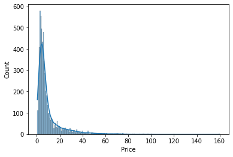

```python
sns.histplot(df["Price"], kde=True)
```

OBSERVATIONS ABOVE:

This is a highly skewed distribution. Let us use log transformation on this column to see of that helps normalise the distribution.

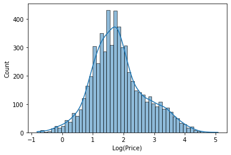

```python
sns.histplot(np.log(df["Price"]), kde=True)
plt.xlabel("Log(Price)")
```

[figure not shown]

```python
# Log Transformation has definitely helped in reducing the skew
# Creating a new column with the transformed variable.
df["price_log"] = np.log(df["Price"])
plt.xlabel('Log(Price)')
```

### **Price vs Location**

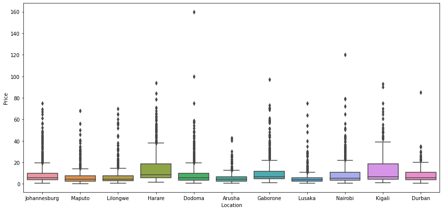

```python
plt.figure(figsize=(15, 7))
sns.boxplot(x="Location", y="Price", data=df)
```

OBSERVATIONS ABOVE:

Price of used cars has a large IQR in Harare and Kigali.

### **Kilometers_Driven**

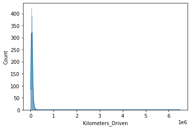

```python
sns.histplot(df["Kilometers_Driven"], kde=True)
```

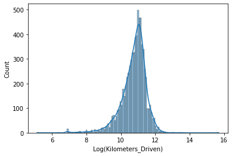

```python
# Log transformation
sns.histplot(np.log(df["Kilometers_Driven"]), kde=True)
plt.xlabel('Log(Kilometers_Driven)')
```

OBSERVATIONS ABOVE:

Transformation has reduced the extreme skewness.

```python
df["kilometers_driven_log"] = np.log(df["Kilometers_Driven"])
```

### Bivariate Distributions

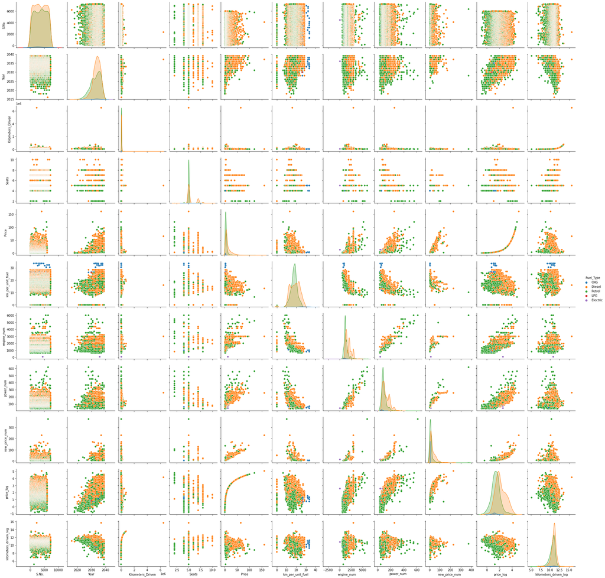

```python
sns.pairplot(df, hue="Fuel_Type")
```

OBSERVATIONS ABOVE:

Zooming into these plots gives us a lot of information.

- Contrary to intuition Kilometers Driven does not seem to have a relationship with price.
- Price has a positive relationship with Year. Newer the car, higher the price.
- S.No. does not capture any information that we were hoping for. The temporal element of variation is captured in the year column.
- 2 seater cars are all luxury variants. Cars with 8-10 seats are exclusively mid to high range.
- Mileage does not seem to show much relationship with the price of used cars.
- Engine displacement and Power of the car have a positive relationship with the price.
- New Price and Used Car Price are also positively correlated, which is expected.
- Kilometers Driven has a peculiar relationship with the Year variable. Generally, newer the car lesser the distance it has travelled, but this is not always true.
- CNG cars are conspicuous outliers when it comes to Mileage. The mileage of these cars is very high.
- Mileage and power of newer cars is increasing owing to advancement in technology.
- Mileage has a negative correlation with engine displacement and power. More powerful the engine, more fuel it consumes in general.

### Correlation between numeric Variables

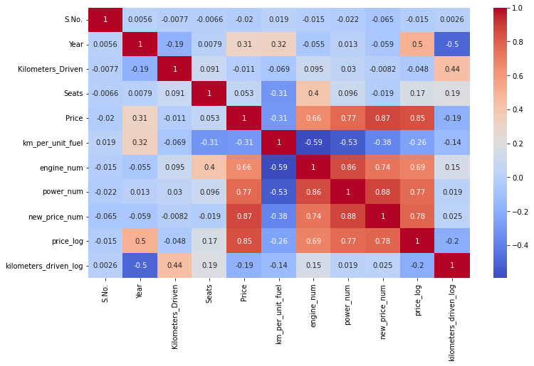

```python
plt.figure(figsize=(12, 7))
sns.heatmap(df.corr(), annot=True, cmap="coolwarm")
```

OBSERVATIONS ABOVE:

- Power and engine are important predictors of price
- We will have to work on imputing New Price missing values because this is a very important feature in predicting used car price accurately

## Missing Value Treatment

```python
# Missing values check once again.
df.isnull().sum()
```

```
S.No.                       0
Name                        0
Location                    0
Year                        0
Kilometers_Driven           0
Fuel_Type                   0
Transmission                0
Owner_Type                  0
Seats                      53
Price                    1234
km_per_unit_fuel            2
engine_num                 46
power_num                 175
new_price_num            6247
Brand                       0
Model                       0
price_log                1234
kilometers_driven_log       0
dtype: int64
```

### Seats

```python
# Look at a few rows where the number of seats is missing.
df[df["Seats"].isnull()]
```

|  | S.No. | Name | Location | Year | Kilometers_Driven | Fuel_Type | Transmission | Owner_Type | Seats | Price | km_per_unit_fuel | engine_num | power_num | new_price_num | Brand | Model | price_log | kilometers_driven_log |
| --- | --- | --- | --- | --- | --- | --- | --- | --- | --- | --- | --- | --- | --- | --- | --- | --- | --- | --- |
| 194 | 194 | Honda City 1.5 GXI | Durban | 2027 | 60006 | Petrol | Manual | First | NaN | 2.95 | 0.00 | NaN | NaN | NaN | honda | city | 1.081805 | 11.002200 |
| 208 | 208 | Maruti Swift 1.3 VXi | Lusaka | 2030 | 42001 | Petrol | Manual | First | NaN | 2.11 | 16.10 | NaN | NaN | NaN | maruti | swift | 0.746688 | 10.645449 |
| 229 | 229 | Ford Figo Diesel | Kigali | 2035 | 70436 | Diesel | Manual | First | NaN | 3.60 | 0.00 | 1498.0 | 99.0 | NaN | ford | figo | 1.280934 | 11.162460 |
| 733 | 733 | Maruti Swift 1.3 VXi | Lilongwe | 2026 | 97800 | Petrol | Manual | Third | NaN | 1.75 | 16.10 | NaN | NaN | NaN | maruti | swift | 0.559616 | 11.490680 |
| 749 | 749 | Land Rover Range Rover 3.0 D | Johannesburg | 2028 | 55001 | Diesel | Automatic | Second | NaN | 26.50 | 0.00 | NaN | NaN | NaN | land | rover | 3.277145 | 10.915107 |
| 1294 | 1294 | Honda City 1.3 DX | Nairobi | 2029 | 55005 | Petrol | Manual | First | NaN | 3.20 | 12.80 | NaN | NaN | NaN | honda | city | 1.163151 | 10.915179 |
| 1327 | 1327 | Maruti Swift 1.3 ZXI | Dodoma | 2035 | 50295 | Petrol | Manual | First | NaN | 5.80 | 16.10 | NaN | NaN | NaN | maruti | swift | 1.757858 | 10.825661 |
| 1385 | 1385 | Honda City 1.5 GXI | Maputo | 2024 | 115000 | Petrol | Manual | Second | NaN | 1.50 | 0.00 | NaN | NaN | NaN | honda | city | 0.405465 | 11.652687 |
| 1460 | 1460 | Land Rover Range Rover Sport 2005 2012 Sport | Harare | 2028 | 69078 | Petrol | Manual | First | NaN | 40.88 | 0.00 | NaN | NaN | NaN | land | rover | 3.710641 | 11.142992 |
| 1917 | 1917 | Honda City 1.5 EXI | Arusha | 2025 | 88000 | Petrol | Manual | Second | NaN | 1.70 | 13.00 | 1493.0 | 100.0 | NaN | honda | city | 0.530628 | 11.385092 |
| 2074 | 2074 | Maruti Swift 1.3 LXI | Maputo | 2031 | 24255 | Petrol | Manual | First | NaN | 3.15 | 16.10 | NaN | NaN | NaN | maruti | swift | 1.147402 | 10.096378 |
| 2096 | 2096 | Hyundai Santro LP zipPlus | Harare | 2024 | 52146 | Petrol | Manual | First | NaN | 1.93 | 0.00 | NaN | NaN | NaN | hyundai | santro | 0.657520 | 10.861803 |
| 2264 | 2264 | Toyota Etios Liva V | Maputo | 2032 | 24500 | Petrol | Manual | Second | NaN | 2.95 | 18.30 | NaN | NaN | NaN | toyota | etios | 1.081805 | 10.106428 |
| 2325 | 2325 | Maruti Swift 1.3 VXI ABS | Maputo | 2035 | 67000 | Petrol | Manual | First | NaN | 4.70 | 16.10 | NaN | NaN | NaN | maruti | swift | 1.547563 | 11.112448 |
| 2335 | 2335 | Maruti Swift 1.3 VXi | Johannesburg | 2027 | 55000 | Petrol | Manual | Second | NaN | 1.75 | 16.10 | NaN | NaN | NaN | maruti | swift | 0.559616 | 10.915088 |
| 2369 | 2369 | Maruti Estilo LXI | Lilongwe | 2028 | 56000 | Petrol | Manual | Second | NaN | 1.50 | 19.50 | 1061.0 | NaN | NaN | maruti | estilo | 0.405465 | 10.933107 |
| 2530 | 2530 | BMW 5 Series 520d Sedan | Gaborone | 2034 | 64158 | Diesel | Automatic | First | NaN | 17.89 | 18.48 | NaN | NaN | NaN | bmw | 5 | 2.884242 | 11.069104 |
| 2542 | 2542 | Hyundai Santro GLS II - Euro II | Kigali | 2031 | 65000 | Petrol | Manual | Second | NaN | 3.15 | 0.00 | NaN | NaN | NaN | hyundai | santro | 1.147402 | 11.082143 |
| 2623 | 2623 | BMW 5 Series 520d Sedan | Maputo | 2032 | 95000 | Diesel | Automatic | Second | NaN | 18.00 | 18.48 | NaN | NaN | NaN | bmw | 5 | 2.890372 | 11.461632 |
| 2668 | 2668 | Maruti Swift 1.3 VXi | Lusaka | 2034 | 32986 | Petrol | Manual | First | NaN | 4.24 | 16.10 | NaN | NaN | NaN | maruti | swift | 1.444563 | 10.403839 |
| 2737 | 2737 | Maruti Wagon R Vx | Arusha | 2021 | 200000 | Petrol | Manual | First | NaN | 0.70 | 12.00 | NaN | NaN | NaN | maruti | wagon | -0.356675 | 12.206073 |
| 2780 | 2780 | Hyundai Santro GLS II - Euro II | Maputo | 2029 | 100000 | Petrol | Manual | First | NaN | 1.60 | 0.00 | NaN | NaN | NaN | hyundai | santro | 0.470004 | 11.512925 |
| 2842 | 2842 | Hyundai Santro GLS II - Euro II | Kigali | 2032 | 43000 | Petrol | Manual | First | NaN | 3.25 | 0.00 | NaN | NaN | NaN | hyundai | santro | 1.178655 | 10.668955 |
| 3272 | 3272 | BMW 5 Series 520d Sedan | Johannesburg | 2028 | 81000 | Diesel | Automatic | Second | NaN | 10.50 | 18.48 | NaN | NaN | NaN | bmw | 5 | 2.351375 | 11.302204 |
| 3404 | 3404 | Maruti Swift 1.3 VXi | Arusha | 2026 | 125000 | Petrol | Manual | Fourth & Above | NaN | 2.35 | 16.10 | NaN | NaN | NaN | maruti | swift | 0.854415 | 11.736069 |
| 3520 | 3520 | BMW 5 Series 520d Sedan | Nairobi | 2032 | 90000 | Diesel | Automatic | First | NaN | 14.50 | 18.48 | NaN | NaN | NaN | bmw | 5 | 2.674149 | 11.407565 |
| 3522 | 3522 | Hyundai Santro GLS II - Euro II | Gaborone | 2032 | 66400 | Petrol | Manual | First | NaN | 2.66 | 0.00 | NaN | NaN | NaN | hyundai | santro | 0.978326 | 11.103452 |
| 3800 | 3800 | Ford Endeavour Hurricane LE | Johannesburg | 2032 | 129000 | Diesel | Automatic | First | NaN | 7.00 | 12.80 | 2953.0 | NaN | NaN | ford | endeavour | 1.945910 | 11.767568 |
| 3810 | 3810 | Honda CR-V AT With Sun Roof | Lusaka | 2033 | 27000 | Petrol | Automatic | First | NaN | 11.99 | 14.00 | NaN | NaN | NaN | honda | cr-v | 2.484073 | 10.203592 |
| 3882 | 3882 | Maruti Estilo LXI | Lusaka | 2030 | 40000 | Petrol | Manual | Second | NaN | 2.50 | 19.50 | 1061.0 | NaN | NaN | maruti | estilo | 0.916291 | 10.596635 |
| 4011 | 4011 | Fiat Punto 1.3 Emotion | Maputo | 2031 | 45271 | Diesel | Manual | First | NaN | 2.60 | 20.30 | NaN | NaN | NaN | fiat | punto | 0.955511 | 10.720422 |
| 4152 | 4152 | Land Rover Range Rover 3.0 D | Johannesburg | 2023 | 75000 | Diesel | Automatic | Second | NaN | 16.11 | 0.00 | NaN | NaN | NaN | land | rover | 2.779440 | 11.225243 |
| 4229 | 4229 | Hyundai Santro Xing XG | Kigali | 2025 | 79000 | Petrol | Manual | Second | NaN | 1.65 | 17.00 | NaN | NaN | NaN | hyundai | santro | 0.500775 | 11.277203 |
| 4577 | 4577 | BMW 5 Series 520d Sedan | Nairobi | 2032 | 72000 | Diesel | Automatic | Third | NaN | 13.85 | 18.48 | NaN | NaN | NaN | bmw | 5 | 2.628285 | 11.184421 |
| 4604 | 4604 | Honda Jazz Select Edition | Maputo | 2031 | 98000 | Petrol | Manual | First | NaN | 3.15 | 16.70 | NaN | NaN | NaN | honda | jazz | 1.147402 | 11.492723 |
| 4697 | 4697 | Fiat Punto 1.2 Dynamic | Gaborone | 2037 | 17941 | Petrol | Manual | First | NaN | 3.93 | 15.70 | NaN | NaN | NaN | fiat | punto | 1.368639 | 9.794844 |
| 4712 | 4712 | Hyundai Santro Xing XG | Maputo | 2023 | 80000 | Petrol | Manual | Second | NaN | 0.90 | 17.00 | NaN | NaN | NaN | hyundai | santro | -0.105361 | 11.289782 |
| 4952 | 4952 | Fiat Punto 1.4 Emotion | Lusaka | 2030 | 47000 | Petrol | Manual | First | NaN | 1.49 | 14.60 | NaN | NaN | NaN | fiat | punto | 0.398776 | 10.757903 |
| 5015 | 5015 | Maruti Swift 1.3 VXi | Nairobi | 2026 | 63000 | Petrol | Manual | First | NaN | 1.60 | 16.10 | NaN | NaN | NaN | maruti | swift | 0.470004 | 11.050890 |
| 5185 | 5185 | Maruti Swift 1.3 LXI | Nairobi | 2032 | 52000 | Petrol | Manual | First | NaN | 3.65 | 16.10 | NaN | NaN | NaN | maruti | swift | 1.294727 | 10.858999 |
| 5270 | 5270 | Honda City 1.5 GXI | Kigali | 2022 | 53000 | Petrol | Manual | Second | NaN | 1.85 | 0.00 | NaN | NaN | NaN | honda | city | 0.615186 | 10.878047 |
| 5893 | 5893 | Maruti Estilo LXI | Lilongwe | 2028 | 51000 | Petrol | Manual | Second | NaN | 1.75 | 19.50 | 1061.0 | NaN | NaN | maruti | estilo | 0.559616 | 10.839581 |
| 6042 | 6042 | Skoda Laura 1.8 TSI Ambition | Kigali | 2029 | 72000 | Petrol | Manual | Second | NaN | NaN | 17.50 | NaN | NaN | NaN | skoda | laura | NaN | 11.184421 |
| 6541 | 6541 | Toyota Etios Liva Diesel TRD Sportivo | Kigali | 2032 | 56600 | Diesel | Manual | First | NaN | NaN | 23.59 | NaN | NaN | NaN | toyota | etios | NaN | 10.943764 |
| 6544 | 6544 | Hyundai i20 new Sportz AT 1.4 | Kigali | 2032 | 58000 | Petrol | Automatic | Second | NaN | NaN | 15.00 | NaN | NaN | NaN | hyundai | i20 | NaN | 10.968198 |
| 6633 | 6633 | Mahindra TUV 300 P4 | Lusaka | 2036 | 27000 | Diesel | Manual | First | NaN | NaN | 0.00 | NaN | NaN | NaN | mahindra | tuv | NaN | 10.203592 |
| 6643 | 6643 | BMW 5 Series 520d Sedan | Kigali | 2029 | 150000 | Diesel | Automatic | Second | NaN | NaN | 18.48 | NaN | NaN | NaN | bmw | 5 | NaN | 11.918391 |
| 6651 | 6651 | Maruti Swift 1.3 VXi | Lusaka | 2035 | 36009 | Petrol | Manual | First | NaN | NaN | 16.10 | NaN | NaN | NaN | maruti | swift | NaN | 10.491524 |
| 6677 | 6677 | Fiat Punto 1.4 Emotion | Arusha | 2030 | 65000 | Petrol | Manual | Third | NaN | NaN | 14.60 | NaN | NaN | NaN | fiat | punto | NaN | 11.082143 |
| 6685 | 6685 | Maruti Swift 1.3 VXi | Maputo | 2030 | 115000 | Petrol | Manual | Second | NaN | NaN | 16.10 | NaN | NaN | NaN | maruti | swift | NaN | 11.652687 |
| 6880 | 6880 | BMW 5 Series 520d Sedan | Lilongwe | 2029 | 95000 | Diesel | Automatic | Second | NaN | NaN | 18.48 | NaN | NaN | NaN | bmw | 5 | NaN | 11.461632 |
| 6902 | 6902 | Toyota Etios Liva V | Gaborone | 2032 | 59311 | Petrol | Manual | First | NaN | NaN | 18.30 | NaN | NaN | NaN | toyota | etios | NaN | 10.990550 |
| 6957 | 6957 | Honda Jazz 2020 Petrol | Gaborone | 2039 | 11574 | Petrol | Manual | First | NaN | NaN | 0.00 | 1199.0 | 88.7 | NaN | honda | jazz | NaN | 9.356516 |

```python
# We'll impute these missing values one by one, by taking median number of seats for the particular car,
# using the Brand and Model name
df.groupby(["Brand", "Model"], as_index=False)["Seats"].median()
```

|  | Brand | Model | Seats |
| --- | --- | --- | --- |
| 0 | ambassador | classic | 5.0 |
| 1 | audi | a3 | 5.0 |
| 2 | audi | a4 | 5.0 |
| 3 | audi | a6 | 5.0 |
| 4 | audi | a7 | 5.0 |
| ... | ... | ... | ... |
| 217 | volvo | s60 | 5.0 |
| 218 | volvo | s80 | 5.0 |
| 219 | volvo | v40 | 5.0 |
| 220 | volvo | xc60 | 5.0 |
| 221 | volvo | xc90 | 7.0 |

222 rows × 3 columns

```python
# Impute missing Seats
df["Seats"] = df.groupby(["Brand", "Model"])["Seats"].transform(
    lambda x: x.fillna(x.median())
)
```

```python
# Check 'Seats'
df[df["Seats"].isnull()]
```

|  | S.No. | Name | Location | Year | Kilometers_Driven | Fuel_Type | Transmission | Owner_Type | Seats | Price | km_per_unit_fuel | engine_num | power_num | new_price_num | Brand | Model | price_log | kilometers_driven_log |
| --- | --- | --- | --- | --- | --- | --- | --- | --- | --- | --- | --- | --- | --- | --- | --- | --- | --- | --- |
| 2369 | 2369 | Maruti Estilo LXI | Lilongwe | 2028 | 56000 | Petrol | Manual | Second | NaN | 1.50 | 19.5 | 1061.0 | NaN | NaN | maruti | estilo | 0.405465 | 10.933107 |
| 3882 | 3882 | Maruti Estilo LXI | Lusaka | 2030 | 40000 | Petrol | Manual | Second | NaN | 2.50 | 19.5 | 1061.0 | NaN | NaN | maruti | estilo | 0.916291 | 10.596635 |
| 5893 | 5893 | Maruti Estilo LXI | Lilongwe | 2028 | 51000 | Petrol | Manual | Second | NaN | 1.75 | 19.5 | 1061.0 | NaN | NaN | maruti | estilo | 0.559616 | 10.839581 |

```python
# Maruti Estilo can accomodate 5
df["Seats"] = df["Seats"].fillna(5.0)
```

```python
# We will use similar methods to fill missing values for engine, power and new price
df["engine_num"] = df.groupby(["Brand", "Model"])["engine_num"].transform(
    lambda x: x.fillna(x.median())
)
df["power_num"] = df.groupby(["Brand", "Model"])["power_num"].transform(
    lambda x: x.fillna(x.median())
)
df["new_price_num"] = df.groupby(["Brand", "Model"])["new_price_num"].transform(
    lambda x: x.fillna(x.median())
)
```

```python
df.isnull().sum()
```

```
S.No.                       0
Name                        0
Location                    0
Year                        0
Kilometers_Driven           0
Fuel_Type                   0
Transmission                0
Owner_Type                  0
Seats                       0
Price                    1234
km_per_unit_fuel            2
engine_num                  0
power_num                  12
new_price_num            1512
Brand                       0
Model                       0
price_log                1234
kilometers_driven_log       0
dtype: int64
```

```python
# There are still some missing values in power, mileage and new_price_num.
# There are a few car brands and models in our dataset that do not contain the new price information at all.
# we will estimate the new price using median of the data.

cols1 = ["power_num","km_per_unit_fuel","new_price_num"]

for ii in cols1:
    df[ii] = df[ii].fillna(df[ii].median())
```

```python
df.isnull().sum()
```

```
S.No.                       0
Name                        0
Location                    0
Year                        0
Kilometers_Driven           0
Fuel_Type                   0
Transmission                0
Owner_Type                  0
Seats                       0
Price                    1234
km_per_unit_fuel            0
engine_num                  0
power_num                   0
new_price_num               0
Brand                       0
Model                       0
price_log                1234
kilometers_driven_log       0
dtype: int64
```

```python
# Drop the redundant columns.
df.drop(columns=["Kilometers_Driven", "Name", "S.No."], inplace=True)

# Drop the rows where 'Price' == NaN and proceed to modelling
df = df[df["Price"].notna()]
```

# Linear Model Building

1. What we want to predict is the "Price". We will use the normalized version 'price_log' for modelling.
2. Before we proceed to modelling, we will have to encode categorical features. We will drop categorical features like - Name.
3. We will split the data into train and test, to be able to evaluate the model that we build on the train data.
4. Build a Linear Regression model using the train data.
5. Evaluate the model performance on test data.

### Define dependent variable

```python
ind_vars = df.drop(["Price", "price_log"], axis=1)
dep_var = df[["price_log"]]   #The logarithm of prices will be the target variable.
```

### Creating dummy variables

```python
def encode_cat_vars(x):
    x = pd.get_dummies(
        x,
        columns=x.select_dtypes(include=["object", "category"]).columns.tolist(),
        drop_first=True,
    )
    return x

ind_vars_num = encode_cat_vars(ind_vars)
ind_vars_num.head()
```

|  | Year | Seats | km_per_unit_fuel | engine_num | power_num | new_price_num | kilometers_driven_log | Location_Dodoma | Location_Durban | Location_Gaborone | Location_Harare | Location_Johannesburg | Location_Kigali | Location_Lilongwe | Location_Lusaka | Location_Maputo | Location_Nairobi | Fuel_Type_Diesel | Fuel_Type_Electric | Fuel_Type_LPG | Fuel_Type_Petrol | Transmission_Manual | Owner_Type_Fourth & Above | Owner_Type_Second | Owner_Type_Third | Brand_audi | Brand_bentley | Brand_bmw | Brand_chevrolet | … |
| --- | --- | --- | --- | --- | --- | --- | --- | --- | --- | --- | --- | --- | --- | --- | --- | --- | --- | --- | --- | --- | --- | --- | --- | --- | --- | --- | --- | --- | --- | --- |
| 0 | 2030 | 5.0 | 26.60 | 998.0 | 58.16 | 5.51 | 11.184421 | 0 | 0 | 0 | 0 | 1 | 0 | 0 | 0 | 0 | 0 | 0 | 0 | 0 | 0 | 1 | 0 | 0 | 0 | 0 | 0 | 0 | 0 | … |
| 1 | 2035 | 5.0 | 19.67 | 1582.0 | 126.20 | 16.06 | 10.621327 | 0 | 0 | 0 | 0 | 0 | 0 | 0 | 0 | 1 | 0 | 1 | 0 | 0 | 0 | 1 | 0 | 0 | 0 | 0 | 0 | 0 | 0 | … |
| 2 | 2031 | 5.0 | 18.20 | 1199.0 | 88.70 | 8.61 | 10.736397 | 0 | 0 | 0 | 0 | 0 | 0 | 1 | 0 | 0 | 0 | 0 | 0 | 0 | 1 | 1 | 0 | 0 | 0 | 0 | 0 | 0 | 0 | … |
| 3 | 2032 | 7.0 | 20.77 | 1248.0 | 88.76 | 11.27 | 11.373663 | 0 | 0 | 0 | 0 | 0 | 0 | 1 | 0 | 0 | 0 | 1 | 0 | 0 | 0 | 1 | 0 | 0 | 0 | 0 | 0 | 0 | 0 | … |
| 4 | 2033 | 5.0 | 15.20 | 1968.0 | 140.80 | 53.14 | 10.613246 | 0 | 0 | 0 | 1 | 0 | 0 | 0 | 0 | 0 | 0 | 1 | 0 | 0 | 0 | 0 | 0 | 1 | 0 | 1 | 0 | 0 | 0 | … |

### Split the data into train and test

```python
from sklearn.model_selection import train_test_split

x_train, x_test, y_train, y_test = train_test_split(
    ind_vars_num, dep_var, test_size=0.3, random_state=1
)
```

```python
print("Number of rows in train data =", x_train.shape[0])
print("Number of rows in train data =", x_test.shape[0])
```

```
Number of rows in train data = 4213
Number of rows in train data = 1806
```

### Fitting a linear model

```python
lin_reg_model = LinearRegression()
lin_reg_model.fit(x_train,y_train)
```

```
LinearRegression()
```

```python
# let us check the coefficients and intercept of the model

coef_df = pd.DataFrame(np.append(lin_reg_model.coef_.flatten(), lin_reg_model.intercept_), \
                       index=x_train.columns.tolist()+['Intercept'], columns=['Coefficients'])
coef_df
```

|  | Coefficients |
| --- | --- |
| Year | 0.106357 |
| Seats | 0.003755 |
| km_per_unit_fuel | -0.000140 |
| engine_num | -0.000124 |
| power_num | 0.003030 |
| ... | ... |
| Model_yeti | 0.298165 |
| Model_z4 | 0.809548 |
| Model_zen | -0.337210 |
| Model_zest | -0.532924 |
| Intercept | -213.487991 |

265 rows × 1 columns

**Let us check the model performance on training data.**

```python
# MAPE
def mape(targets, predictions):
    return np.mean(np.abs((targets - predictions)) / targets) * 100

# Adjusted R^2
def adj_r2(ind_vars, targets, predictions):
    r2 = r2_score(targets, predictions)
    n = ind_vars.shape[0]
    k = ind_vars.shape[1]
    return 1-((1-r2)*(n-1)/(n-k-1))

# Model performance check
def model_perf(model, inp, out):

    y_pred = np.exp(model.predict(inp))
    y_act = np.exp(out.values)

    return pd.DataFrame({
                "RMSE": np.sqrt(mean_squared_error(y_act, y_pred)),
                "MAE": mean_absolute_error(y_act, y_pred),
                "MAPE": mape(y_act, y_pred),
                "R^2": r2_score(y_act, y_pred),
                "Adjusted R^2": adj_r2(inp, y_act, y_pred)
           }, index=[0])
```

```python
# Checking model performance on train set
print('Training Performance\n')
print(model_perf(lin_reg_model, x_train, y_train))
```

```
Training Performance

       RMSE       MAE       MAPE       R^2  Adjusted R^2
0  2.726211  1.196561  12.983262  0.941875      0.937989
```

- Both the R-squared and Adjusted R squared of our model are very high. This is a clear indication that we have been able to create a very good model that is able to explain variance in price of used cars for up to 94%.
- The model is not an underfitting model.
- Let us do a quick performance check on the test data.

```python
# Checking model performance on test set
print('Test Performance\n')
print(model_perf(lin_reg_model, x_test, y_test))
```

```
Test Performance

       RMSE       MAE       MAPE       R^2  Adjusted R^2
0  3.397028  1.360523  13.039766  0.902826      0.886179
```

**Our current model is extremely complex. Let us first bin the Brand and Model columns as it will help us make the dataset more managable.**

```python
df.groupby(["Brand", "Model"])["new_price_num"].mean().sort_values(ascending=False)
```

```
Brand          Model
mercedes-benz  s-class    171.000000
bmw            7          157.230769
porsche        cayenne    136.000000
audi           rs5        128.000000
land           rover      119.887000
                             ...
maruti         eeco         4.900000
renault        kwid         4.794750
hyundai        santro       4.550000
maruti         alto         4.366364
datsun         redi-go      4.153333
Name: new_price_num, Length: 215, dtype: float64
```

**We will create a new variable Car Category by binning the new_price_num**

```python
# Create a new variable - Car Category
df1 = df.copy()
df1["car_category"] = pd.cut(
    x=df["new_price_num"],
    bins=[0, 15, 30, 50, 200],
    labels=["Budget_Friendly", "Mid-Range", "Luxury_Cars", "Ultra_luxury"],
)
df1["car_category"].value_counts()
```

```
Budget_Friendly    4292
Mid-Range           653
Ultra_luxury        567
Luxury_Cars         506
Name: car_category, dtype: int64
```

```python
# Drop the Brand and Model and new_price_num columns.
df1.drop(columns=["Brand", "Model", "new_price_num"], axis=1, inplace=True)

# We will have to create the x and y datasets again
ind_vars = df1.drop(["Price", "price_log"], axis=1)
dep_var = df1[["price_log"]]

# Dummy encoding
ind_vars_num = encode_cat_vars(ind_vars)

# Splitting data into train and test
x_train2, x_test2, y_train, y_test = train_test_split(
    ind_vars_num, dep_var, test_size=0.3, random_state=1
)

print("Number of rows in train data =", x_train2.shape[0])
print("Number of rows in train data =", x_test2.shape[0])
```

```
Number of rows in train data = 4213
Number of rows in train data = 1806
```

```python
# fitting linear regression model
lin_reg_model2 = LinearRegression()
lin_reg_model2.fit(x_train2,y_train)

# let us check the coefficients and intercept of the model

coef_df = pd.DataFrame(np.append(lin_reg_model2.coef_.flatten(), lin_reg_model2.intercept_), \
                       index=x_train2.columns.tolist()+['Intercept'], columns=['Coefficients'])
coef_df
```

|  | Coefficients |
| --- | --- |
| Year | 0.115131 |
| Seats | 0.000871 |
| km_per_unit_fuel | -0.014030 |
| engine_num | 0.000100 |
| power_num | 0.006648 |
| kilometers_driven_log | -0.076654 |
| Location_Dodoma | 0.198970 |
| Location_Durban | 0.055594 |
| Location_Gaborone | 0.038273 |
| Location_Harare | 0.169347 |
| Location_Johannesburg | 0.019783 |
| Location_Kigali | 0.238593 |
| Location_Lilongwe | 0.099942 |
| Location_Lusaka | -0.149805 |
| Location_Maputo | 0.022774 |
| Location_Nairobi | 0.027295 |
| Fuel_Type_Diesel | 0.198016 |
| Fuel_Type_Electric | 1.294086 |
| Fuel_Type_LPG | -0.012212 |
| Fuel_Type_Petrol | -0.092898 |
| Transmission_Manual | -0.188035 |
| Owner_Type_Fourth & Above | 0.076091 |
| Owner_Type_Second | -0.065879 |
| Owner_Type_Third | -0.176361 |
| car_category_Mid-Range | 0.209393 |
| car_category_Luxury_Cars | 0.381921 |
| car_category_Ultra_luxury | 0.433756 |
| Intercept | -232.196085 |

```python
# Checking model performance on train set
print('Training Performance\n')
print(model_perf(lin_reg_model2, x_train2, y_train))

# Checking model performance on test set
print('\n\nTest Performance\n')
print(model_perf(lin_reg_model2, x_test2, y_test))
```

```
Training Performance

       RMSE       MAE       MAPE       R^2  Adjusted R^2
0  6.083325  2.207135  22.512924  0.710584      0.708717


Test Performance

       RMSE       MAE      MAPE       R^2  Adjusted R^2
0  4.688282  2.036767  20.01888  0.814912      0.812101
```

- Binning the car brands and models has drastically reduced the model performance.
- Let us try using forward feature selection to see if we can improve the model performance.

### Forward Feature Selection

```python
import six
import sys
sys.modules['sklearn.externals.six'] = six
import joblib
sys.modules['sklearn.externals.joblib'] = joblib
```

```python
from mlxtend.feature_selection import SequentialFeatureSelector as sfs

reg = LinearRegression()

# Build step forward feature selection
sfs1 = sfs(reg,k_features = x_train2.shape[1], forward=True,   # k_features denotes "Number of features to select"
           floating=False, scoring= 'r2',
           verbose=2, cv=5)

# Perform SFFS
sfs1 = sfs1.fit(x_train2, y_train)
```

[output not shown]

[output cut: 54 more lines]

```
[Parallel(n_jobs=1)]: Done   4 out of   4 | elapsed:    0.2s finished

[2021-12-19 04:41:31] Features: 24/27 -- score: 0.8924199445442034[Parallel(n_jobs=1)]: Using backend SequentialBackend with 1 concurrent workers.
[Parallel(n_jobs=1)]: Done   1 out of   1 | elapsed:    0.1s remaining:    0.0s
[Parallel(n_jobs=1)]: Done   3 out of   3 | elapsed:    0.2s finished

[2021-12-19 04:41:31] Features: 25/27 -- score: 0.8923546718699878[Parallel(n_jobs=1)]: Using backend SequentialBackend with 1 concurrent workers.
[Parallel(n_jobs=1)]: Done   1 out of   1 | elapsed:    0.1s remaining:    0.0s
[Parallel(n_jobs=1)]: Done   2 out of   2 | elapsed:    0.1s finished

[2021-12-19 04:41:31] Features: 26/27 -- score: 0.8922662178308153[Parallel(n_jobs=1)]: Using backend SequentialBackend with 1 concurrent workers.
[Parallel(n_jobs=1)]: Done   1 out of   1 | elapsed:    0.1s remaining:    0.0s
[Parallel(n_jobs=1)]: Done   1 out of   1 | elapsed:    0.1s finished

[2021-12-19 04:41:31] Features: 27/27 -- score: 0.892158002559418
```

- Now we will change k_features to 20.

```python
reg = LinearRegression()

# # Build step forward feature selection
sfs1 = sfs(reg, k_features = 20, forward=True,
           floating=False, scoring='r2',
           verbose=2, cv=5)

# Perform SFFS
sfs1 = sfs1.fit(x_train2, y_train)
```

[output not shown]

[output cut: 26 more lines]

```
[Parallel(n_jobs=1)]: Done  11 out of  11 | elapsed:    0.7s finished

[2021-12-19 04:44:19] Features: 17/20 -- score: 0.8925027532698318[Parallel(n_jobs=1)]: Using backend SequentialBackend with 1 concurrent workers.
[Parallel(n_jobs=1)]: Done   1 out of   1 | elapsed:    0.1s remaining:    0.0s
[Parallel(n_jobs=1)]: Done  10 out of  10 | elapsed:    0.7s finished

[2021-12-19 04:44:19] Features: 18/20 -- score: 0.8925838619738446[Parallel(n_jobs=1)]: Using backend SequentialBackend with 1 concurrent workers.
[Parallel(n_jobs=1)]: Done   1 out of   1 | elapsed:    0.0s remaining:    0.0s
[Parallel(n_jobs=1)]: Done   9 out of   9 | elapsed:    0.6s finished

[2021-12-19 04:44:20] Features: 19/20 -- score: 0.8926232854934975[Parallel(n_jobs=1)]: Using backend SequentialBackend with 1 concurrent workers.
[Parallel(n_jobs=1)]: Done   1 out of   1 | elapsed:    0.1s remaining:    0.0s
[Parallel(n_jobs=1)]: Done   8 out of   8 | elapsed:    0.6s finished

[2021-12-19 04:44:21] Features: 20/20 -- score: 0.8926138765663639
```

```python
# Now Which features are important?
feat_cols = list(sfs1.k_feature_idx_)
print(feat_cols)
```

```
[0, 2, 3, 4, 5, 6, 9, 11, 12, 13, 16, 17, 18, 19, 20, 22, 23, 24, 25, 26]
```

```python
x_train2.columns[feat_cols]
```

```
Index(['Year', 'km_per_unit_fuel', 'engine_num', 'power_num',
       'kilometers_driven_log', 'Location_Dodoma', 'Location_Harare',
       'Location_Kigali', 'Location_Lilongwe', 'Location_Lusaka',
       'Fuel_Type_Diesel', 'Fuel_Type_Electric', 'Fuel_Type_LPG',
       'Fuel_Type_Petrol', 'Transmission_Manual', 'Owner_Type_Second',
       'Owner_Type_Third', 'car_category_Mid-Range',
       'car_category_Luxury_Cars', 'car_category_Ultra_luxury'],
      dtype='object')
```

**Now we will fit a sklearn model using these features only.**

```python
x_train3 = x_train2[x_train2.columns[feat_cols]]
```

```python
x_test2.columns
```

```
Index(['Year', 'Seats', 'km_per_unit_fuel', 'engine_num', 'power_num',
       'kilometers_driven_log', 'Location_Dodoma', 'Location_Durban',
       'Location_Gaborone', 'Location_Harare', 'Location_Johannesburg',
       'Location_Kigali', 'Location_Lilongwe', 'Location_Lusaka',
       'Location_Maputo', 'Location_Nairobi', 'Fuel_Type_Diesel',
       'Fuel_Type_Electric', 'Fuel_Type_LPG', 'Fuel_Type_Petrol',
       'Transmission_Manual', 'Owner_Type_Fourth & Above', 'Owner_Type_Second',
       'Owner_Type_Third', 'car_category_Mid-Range',
       'car_category_Luxury_Cars', 'car_category_Ultra_luxury'],
      dtype='object')
```

```python
#Creating new x_test with the same 20 variables that we selected for x_train
x_test3 = x_test2[x_train3.columns]
```

```python
#Fitting linear model
lin_reg_model3 = LinearRegression()
lin_reg_model3.fit(x_train3,y_train)

# let us check the coefficients and intercept of the model

coef_df = pd.DataFrame(np.append(lin_reg_model3.coef_.flatten(), lin_reg_model3.intercept_.flatten()), \
                       index=x_train3.columns.tolist()+['Intercept'], columns=['Coefficients'])
print(coef_df)

# model performance on train set
print('\n\nTraining Performance\n')
print(model_perf(lin_reg_model3, x_train3, y_train))

# model performance on test set
print('\n\nTest Performance\n')
print(model_perf(lin_reg_model3, x_test3, y_test))
```

```
                           Coefficients
Year                           0.115536
km_per_unit_fuel              -0.014122
engine_num                     0.000102
power_num                      0.006639
kilometers_driven_log         -0.076376
Location_Dodoma                0.173752
Location_Harare                0.143002
Location_Kigali                0.213555
Location_Lilongwe              0.075928
Location_Lusaka               -0.175024
Fuel_Type_Diesel               0.195257
Fuel_Type_Electric             1.285556
Fuel_Type_LPG                 -0.018037
Fuel_Type_Petrol              -0.095679
Transmission_Manual           -0.188294
Owner_Type_Second             -0.067342
Owner_Type_Third              -0.180395
car_category_Mid-Range         0.210796
car_category_Luxury_Cars       0.381237
car_category_Ultra_luxury      0.434269
Intercept                   -232.988879


Training Performance

       RMSE       MAE       MAPE       R^2  Adjusted R^2
0  6.084228  2.206711  22.536053  0.710498      0.709117


Test Performance

       RMSE       MAE       MAPE       R^2  Adjusted R^2
0  4.697141  2.042545  20.090918  0.814212       0.81213
```

- Even with forward feature selection we did not achieve good performance.
- We will now try forward feature selection with the data before binning the car brands and models.

```python
from mlxtend.feature_selection import SequentialFeatureSelector as sfs

reg = LinearRegression()

n_features = list(range(5,55,5))

for item in n_features:
    # Build step forward feature selection
    sfs1 = sfs(reg, k_features = item, forward=True,   # k_features denotes "Number of features to select"
               floating=False, scoring= 'r2',
               verbose=0, n_jobs=-2, cv=5)

    # Perform SFFS
    sfs1 = sfs1.fit(x_train, y_train)
    print('R^2:', sfs1.k_score_, '\nFeatures used:', item, sfs1.k_feature_names_, '\n')
```

```
R^2: 0.86300743060941
Features used: 5 ('Year', 'power_num', 'new_price_num', 'Fuel_Type_Diesel', 'Brand_tata')

R^2: 0.8911814806833611
Features used: 10 ('Year', 'km_per_unit_fuel', 'power_num', 'new_price_num', 'Location_Lusaka', 'Fuel_Type_Diesel', 'Transmission_Manual', 'Brand_chevrolet', 'Brand_mini', 'Brand_tata')

R^2: 0.9037684099952449
Features used: 15 ('Year', 'km_per_unit_fuel', 'power_num', 'new_price_num', 'Location_Dodoma', 'Location_Lusaka', 'Fuel_Type_Diesel', 'Transmission_Manual', 'Brand_chevrolet', 'Brand_mercedes-benz', 'Brand_mini', 'Brand_tata', 'Brand_toyota', 'Model_cayenne', 'Model_q5')

R^2: 0.9126608106067193
Features used: 20 ('Year', 'km_per_unit_fuel', 'power_num', 'new_price_num', 'kilometers_driven_log', 'Location_Dodoma', 'Location_Harare', 'Location_Kigali', 'Location_Lusaka', 'Fuel_Type_Diesel', 'Transmission_Manual', 'Brand_chevrolet', 'Brand_mercedes-benz', 'Brand_mini', 'Brand_tata', 'Brand_to…

R^2: 0.9169897331368867
Features used: 25 ('Year', 'km_per_unit_fuel', 'power_num', 'new_price_num', 'kilometers_driven_log', 'Location_Dodoma', 'Location_Harare', 'Location_Kigali', 'Location_Lusaka', 'Fuel_Type_Diesel', 'Transmission_Manual', 'Brand_chevrolet', 'Brand_mercedes-benz', 'Brand_mini', 'Brand_tata', 'Brand_to…

R^2: 0.9210242726591901
Features used: 30 ('Year', 'km_per_unit_fuel', 'power_num', 'new_price_num', 'kilometers_driven_log', 'Location_Dodoma', 'Location_Harare', 'Location_Kigali', 'Location_Lusaka', 'Fuel_Type_Diesel', 'Transmission_Manual', 'Brand_bmw', 'Brand_chevrolet', 'Brand_mercedes-benz', 'Brand_mini', 'Brand_por…

R^2: 0.9260504398498034
Features used: 35 ('Year', 'km_per_unit_fuel', 'engine_num', 'power_num', 'new_price_num', 'kilometers_driven_log', 'Location_Dodoma', 'Location_Harare', 'Location_Kigali', 'Location_Lusaka', 'Fuel_Type_Diesel', 'Transmission_Manual', 'Brand_audi', 'Brand_bmw', 'Brand_chevrolet', 'Brand_jaguar', 'Br…

R^2: 0.9293846163745577
Features used: 40 ('Year', 'km_per_unit_fuel', 'engine_num', 'power_num', 'new_price_num', 'kilometers_driven_log', 'Location_Dodoma', 'Location_Harare', 'Location_Kigali', 'Location_Lusaka', 'Fuel_Type_Diesel', 'Transmission_Manual', 'Brand_audi', 'Brand_bmw', 'Brand_chevrolet', 'Brand_datsun', 'Br…

R^2: 0.9319214758999879
Features used: 45 ('Year', 'km_per_unit_fuel', 'engine_num', 'power_num', 'new_price_num', 'kilometers_driven_log', 'Location_Dodoma', 'Location_Harare', 'Location_Kigali', 'Location_Lusaka', 'Fuel_Type_Diesel', 'Transmission_Manual', 'Brand_audi', 'Brand_bmw', 'Brand_chevrolet', 'Brand_datsun', 'Br…

R^2: 0.9340184463617787
Features used: 50 ('Year', 'km_per_unit_fuel', 'engine_num', 'power_num', 'new_price_num', 'kilometers_driven_log', 'Location_Dodoma', 'Location_Harare', 'Location_Kigali', 'Location_Lilongwe', 'Location_Lusaka', 'Fuel_Type_Diesel', 'Transmission_Manual', 'Owner_Type_Second', 'Brand_audi', 'Brand_bm…
```

**We see that after 35 best features, adding more features does not result in a significant increase in performance. So we will move forward with 35 best features, and make a linear regression model using only these features.**

```python
# Build step forward feature selection
sfs1 = sfs(reg, k_features = 35, forward=True,   # k_features denotes "Number of features to select"
           floating=False, scoring= 'r2',
           verbose=0, n_jobs=-2, cv=5)

# Perform SFFS
sfs1 = sfs1.fit(x_train, y_train)
feat_cols = list(sfs1.k_feature_names_)

# take the best columns as per forward feature selection
X_train_final = x_train[feat_cols]
X_test_final = x_test[feat_cols]

print(X_train_final.shape, X_test_final.shape)
X_train_final.head()
```

```
(4213, 35) (1806, 35)
```

|  | Year | km_per_unit_fuel | engine_num | power_num | new_price_num | kilometers_driven_log | Location_Dodoma | Location_Harare | Location_Kigali | Location_Lusaka | Fuel_Type_Diesel | Transmission_Manual | Brand_audi | Brand_bmw | Brand_chevrolet | Brand_jaguar | Brand_land | Brand_mercedes-benz | Brand_mini | Brand_porsche | Brand_tata | Brand_toyota | Brand_volvo | Model_a4 | Model_cayenne | Model_ciaz | Model_city | Model_creta | Model_e-class | … |
| --- | --- | --- | --- | --- | --- | --- | --- | --- | --- | --- | --- | --- | --- | --- | --- | --- | --- | --- | --- | --- | --- | --- | --- | --- | --- | --- | --- | --- | --- | --- |
| 188 | 2032 | 22.32 | 1582.0 | 126.32 | 14.255 | 11.034890 | 0 | 0 | 0 | 0 | 1 | 1 | 0 | 0 | 0 | 0 | 0 | 0 | 0 | 0 | 0 | 0 | 0 | 0 | 0 | 0 | 0 | 0 | 0 | … |
| 4178 | 2034 | 22.32 | 1582.0 | 126.32 | 14.255 | 11.461632 | 0 | 0 | 1 | 0 | 1 | 1 | 0 | 0 | 0 | 0 | 0 | 0 | 0 | 0 | 0 | 0 | 0 | 0 | 0 | 0 | 0 | 0 | 0 | … |
| 3888 | 2037 | 18.70 | 1199.0 | 88.70 | 9.600 | 10.644972 | 0 | 0 | 0 | 0 | 0 | 1 | 0 | 0 | 0 | 0 | 0 | 0 | 0 | 0 | 0 | 0 | 0 | 0 | 0 | 0 | 0 | 0 | 0 | … |
| 2242 | 2030 | 14.24 | 2755.0 | 174.50 | 37.510 | 11.608236 | 1 | 0 | 0 | 0 | 1 | 1 | 0 | 0 | 0 | 0 | 0 | 0 | 0 | 0 | 0 | 1 | 0 | 0 | 0 | 0 | 0 | 0 | 0 | … |
| 2594 | 2036 | 18.60 | 1197.0 | 81.83 | 10.250 | 10.545341 | 0 | 0 | 0 | 0 | 0 | 1 | 0 | 0 | 0 | 0 | 0 | 0 | 0 | 0 | 0 | 0 | 0 | 0 | 0 | 0 | 0 | 0 | 0 | … |

```python
#Fitting linear model
lin_reg_model4 = LinearRegression()
lin_reg_model4.fit(X_train_final,y_train)

# let us check the coefficients and intercept of the model

coef_df = pd.DataFrame(np.append(lin_reg_model4.coef_.flatten(), lin_reg_model4.intercept_.flatten()), \
                       index=X_train_final.columns.tolist()+['Intercept'], columns=['Coefficients'])
print(coef_df)

# model performance on train set
print('\n\nTraining Performance\n')
print(model_perf(lin_reg_model4, X_train_final, y_train))

# model performance on test set
print('\n\nTest Performance\n')
print(model_perf(lin_reg_model4, X_test_final, y_test))
```

```
                       Coefficients
Year                       0.119840
km_per_unit_fuel          -0.012846
engine_num                 0.000168
power_num                  0.004785
new_price_num              0.002851
kilometers_driven_log     -0.062610
Location_Dodoma            0.161062
Location_Harare            0.136486
Location_Kigali            0.178041
Location_Lusaka           -0.179524
Fuel_Type_Diesel           0.279734
Transmission_Manual       -0.121792
Brand_audi                 0.426867
Brand_bmw                  0.447319
Brand_chevrolet           -0.286448
Brand_jaguar               0.491293
Brand_land                 0.583024
Brand_mercedes-benz        0.581296
Brand_mini                 0.960500
Brand_porsche              1.190241
Brand_tata                -0.481735
Brand_toyota               0.325789
Brand_volvo                0.451240
Model_a4                   0.086900
Model_cayenne             -1.820691
Model_ciaz                 0.236408
Model_city                 0.160971
Model_creta                0.290411
Model_e-class             -0.225508
Model_ertiga               0.271820
Model_etios               -0.299942
Model_figo                -0.209747
Model_q5                   0.408824
Model_x5                   0.251262
Model_xylo                -0.471842
Intercept               -242.003458


Training Performance

       RMSE     MAE       MAPE       R^2  Adjusted R^2
0  4.372262  1.7347  17.821442  0.850496      0.849243


Test Performance

       RMSE       MAE       MAPE       R^2  Adjusted R^2
0  3.584124  1.593298  16.749499  0.891828      0.889689
```

# Observations and Conclusions

1. With our linear regression model we have been able to capture ~85% variation in the data set.
2. The model indicates that the most significant predictors of price of used cars are:
   - The year of manufacturing
   - Price of new car
   - Power of the engine
   - Mileage
   - Kilometers Driven
   - Location
   - Fuel_Type
   - Transmission - Automatic/Manual
   - Car Brand
   - Car Model
1. Newer cars sell for higher prices. One unit increase in the year of manufacture leads to exp(0.1198) = 1.13 Rivers increase in the price of the vehicle, when everything else is constant.

**It is important to note here that the predicted values are log(price) and therefore coefficients have to converted accordingly to understand that influence in Price.**

1. As the price of a new car of same model increases by one unit, the price of the used car increases by exp(0.0029) = 1.00 Rivers.
2. Mileage is inversely correlated with Price. Generally, high Mileage cars are the lower budget cars.

**It is important to note here that correlation is not equal to causation. That is to say that increase in Mileage does not lead to a drop in prices. It can be understood in such a way that the cars with high mileage do not have a high power engine and therefore have low prices.**

1. Kilometers Driven have a negative relationship with the price which is intuitive. A car that has been driven more will have more wear and tear and hence sell at a lower price.
2. The categorical variables are a little hard to interpret. But it can be seen that most of the Brand and Model variables in the dataset have a positive relationship with the Price and the magnitude of this positive relationship increases as the brand category moves to the luxury brands.

# Business Insights and Recommendations

### Analysing predictions where we were way off the mark

```python
# Extracting the rows from original data frame df where indexes are same as the training data
original_df = df[df.index.isin(X_train_final.index.values)].copy()

# Extracting predicted values and residuals from the final model
fitted_values = lin_reg_model4.predict(X_train_final)
residuals = fitted_values - y_train

# Add new columns for predicted values
original_df["Predicted price_log "] = fitted_values
original_df["Predicted Price"] = np.exp(fitted_values)
original_df["residuals"] = residuals
original_df["Abs_residuals"] = np.exp(residuals)
original_df["Difference in Rivers"] = np.abs(
    original_df["Price"] - original_df["Predicted Price"]
)

# Let us look at the top 50 predictions where our model made highest extimation errors (on train data)
original_df.sort_values(by=["Difference in Rivers"], ascending=False).head(50)
```

|  | Location | Year | Fuel_Type | Transmission | Owner_Type | Seats | Price | km_per_unit_fuel | engine_num | power_num | new_price_num | Brand | Model | price_log | kilometers_driven_log | Predicted price_log | Predicted Price | residuals | Abs_residuals | Difference in Rivers |
| --- | --- | --- | --- | --- | --- | --- | --- | --- | --- | --- | --- | --- | --- | --- | --- | --- | --- | --- | --- | --- |
| 4079 | Dodoma | 2037 | Diesel | Automatic | First | 5.0 | 160.00 | 13.33 | 2993.0 | 255.00 | 230.000 | land | rover | 5.075174 | 10.126631 | 0.976720 | 2.655732 | -0.367301 | 0.692601 | 157.344268 |
| 5462 | Durban | 2030 | Diesel | Manual | First | 5.0 | 2.75 | 19.30 | 1248.0 | 73.90 | 7.880 | maruti | swift | 1.011601 | 11.326596 | 5.008650 | 149.702556 | 0.046979 | 1.048100 | 146.952556 |
| 3212 | Dodoma | 2034 | Diesel | Manual | First | 7.0 | 12.99 | 12.80 | 2494.0 | 102.00 | 24.010 | toyota | innova | 2.564180 | 11.975357 | 5.074579 | 159.904783 | -0.106873 | 0.898639 | 146.914783 |
| 2405 | Harare | 2037 | Petrol | Manual | First | 5.0 | 6.42 | 18.16 | 1196.0 | 86.80 | 7.650 | ford | figo | 1.859418 | 9.986909 | 4.871502 | 130.516745 | -0.164093 | 0.848663 | 124.096745 |
| 3439 | Maputo | 2030 | Diesel | Manual | Second | 5.0 | 3.10 | 17.80 | 1248.0 | 74.00 | 7.880 | maruti | swift | 1.131402 | 11.060369 | 4.819972 | 123.961630 | -0.036407 | 0.964248 | 120.861630 |
| 5781 | Nairobi | 2031 | Petrol | Automatic | Third | 2.0 | 120.00 | 6.40 | 5204.0 | 560.00 | 11.685 | lamborghini | gallardo | 4.787492 | 8.779557 | 1.121061 | 3.068109 | -0.440924 | 0.643442 | 116.931891 |
| 436 | Gaborone | 2036 | Petrol | Manual | First | 5.0 | 3.74 | 22.74 | 796.0 | 47.30 | 4.360 | maruti | alto | 1.319086 | 10.441938 | 4.704686 | 110.463613 | -0.023199 | 0.977068 | 106.723613 |
| 1363 | Harare | 2038 | Petrol | Automatic | First | 5.0 | 7.55 | 18.90 | 1197.0 | 81.86 | 8.630 | hyundai | grand | 2.021548 | 9.936294 | 4.707873 | 110.816203 | 0.098144 | 1.103121 | 103.266203 |
| 1505 | Gaborone | 2039 | Diesel | Automatic | First | 5.0 | 97.07 | 12.65 | 2993.0 | 255.00 | 139.000 | land | rover | 4.575432 | 10.166352 | 1.234604 | 3.437016 | -0.042115 | 0.958760 | 93.632984 |
| 3150 | Nairobi | 2035 | Diesel | Manual | First | 5.0 | 7.65 | 22.70 | 1598.0 | 118.00 | 11.685 | maruti | s | 2.034706 | 9.717580 | 4.598643 | 99.349410 | -0.039243 | 0.961517 | 91.699410 |
| 1984 | Kigali | 2037 | Petrol | Automatic | First | 5.0 | 93.00 | 12.05 | 2979.0 | 320.00 | 158.000 | bmw | 7 | 4.532599 | 9.767954 | 0.695786 | 2.005284 | -0.080887 | 0.922298 | 90.994716 |
| 4271 | Nairobi | 2030 | Petrol | Automatic | First | 5.0 | 3.55 | 16.80 | 1497.0 | 118.00 | 13.580 | honda | city | 1.266948 | 11.034890 | 4.533318 | 93.066807 | 0.114102 | 1.120867 | 89.516807 |
| 1974 | Harare | 2038 | Petrol | Automatic | First | 5.0 | 93.67 | 12.05 | 2979.0 | 320.00 | 158.000 | bmw | 7 | 4.539778 | 10.242100 | 1.445346 | 4.243320 | -0.039467 | 0.961301 | 89.426680 |
| 1158 | Lilongwe | 2031 | Diesel | Manual | Third | 5.0 | 3.50 | 21.50 | 1248.0 | 88.80 | 11.685 | maruti | sx4 | 1.252763 | 11.289782 | 4.521601 | 91.982743 | -0.018159 | 0.982005 | 88.482743 |
| 4438 | Arusha | 2039 | Petrol | Manual | First | 5.0 | 3.50 | 24.70 | 796.0 | 47.30 | 4.360 | maruti | alto | 1.252763 | 8.006368 | 4.500310 | 90.045083 | 0.529957 | 1.698859 | 86.545083 |
| 4691 | Kigali | 2034 | Petrol | Automatic | Second | 2.0 | 90.00 | 12.00 | 5461.0 | 421.00 | 11.685 | mercedes-benz | slk-class | 4.499810 | 8.006368 | 1.678692 | 5.358542 | 0.320162 | 1.377351 | 84.641458 |
| 4470 | Lusaka | 2033 | Diesel | Manual | First | 5.0 | 3.30 | 27.40 | 1498.0 | 98.60 | 8.540 | honda | amaze | 1.193922 | 10.747208 | 4.451712 | 85.773685 | 0.138917 | 1.149029 | 82.473685 |
| 5109 | Nairobi | 2035 | Diesel | Manual | First | 5.0 | 3.96 | 24.00 | 1120.0 | 70.00 | 7.450 | hyundai | grand | 1.376244 | 11.063132 | 4.459282 | 86.425475 | 0.196279 | 1.216867 | 82.465475 |
| 1274 | Dodoma | 2035 | Petrol | Manual | First | 7.0 | 2.95 | 15.10 | 1196.0 | 73.00 | 4.830 | maruti | eeco | 1.081805 | 11.412143 | 4.427631 | 83.732844 | 0.484169 | 1.622825 | 80.782844 |
| 1365 | Arusha | 2030 | Diesel | Manual | Second | 5.0 | 1.60 | 18.80 | 1248.0 | 90.00 | 11.685 | tata | manza | 0.470004 | 11.513225 | 4.407891 | 82.096113 | 0.189461 | 1.208598 | 80.496113 |
| 5535 | Durban | 2035 | Diesel | Automatic | First | 5.0 | 85.00 | 15.87 | 2993.0 | 308.43 | 11.685 | bmw | x6 | 4.442651 | 11.482497 | 1.580385 | 4.856825 | -0.755468 | 0.469791 | 80.143175 |
| 577 | Lilongwe | 2024 | Petrol | Manual | Third | 5.0 | 1.50 | 13.80 | 1299.0 | 70.00 | 11.685 | ford | ikon | 0.405465 | 11.767568 | 4.400354 | 81.479687 | -0.301867 | 0.739436 | 79.979687 |
| 2095 | Harare | 2039 | Petrol | Automatic | First | 2.0 | 83.96 | 19.00 | 2996.0 | 362.07 | 106.000 | mercedes-benz | slc | 4.430340 | 7.834392 | 1.563927 | 4.777547 | 0.441161 | 1.554511 | 79.182453 |
| 3102 | Maputo | 2030 | Diesel | Manual | Second | 5.0 | 3.20 | 20.00 | 1399.0 | 68.00 | 7.650 | ford | figo | 1.163151 | 11.775182 | 4.397734 | 81.266470 | -0.354928 | 0.701224 | 78.066470 |
| 2422 | Nairobi | 2036 | Diesel | Automatic | First | 4.0 | 79.00 | 10.50 | 2993.0 | 271.23 | 11.685 | jaguar | xj | 4.369448 | 9.392662 | 1.624128 | 5.073994 | -0.496616 | 0.608587 | 73.926006 |
| 3489 | Kigali | 2033 | Diesel | Automatic | Second | 4.0 | 75.00 | 17.85 | 2967.0 | 300.00 | 11.685 | porsche | panamera | 4.317488 | 9.894850 | 0.897932 | 2.454523 | 0.080245 | 1.083553 | 72.545477 |
| 4180 | Harare | 2037 | Diesel | Manual | First | 5.0 | 11.45 | 20.50 | 1582.0 | 126.20 | 19.180 | hyundai | creta | 2.437990 | 11.523519 | 4.424648 | 83.483381 | 0.197157 | 1.217935 | 72.033381 |
| 655 | Johannesburg | 2037 | Petrol | Automatic | First | 5.0 | 75.00 | 9.43 | 1999.0 | 237.40 | 11.685 | jaguar | xj | 4.317488 | 9.259226 | 1.191643 | 3.292488 | -0.911209 | 0.402038 | 71.707512 |
| 5065 | Dodoma | 2036 | Diesel | Manual | First | 5.0 | 5.99 | 17.80 | 1248.0 | 74.00 | 7.880 | maruti | swift | 1.790091 | 11.066638 | 4.346568 | 77.213023 | 0.184615 | 1.202755 | 71.223023 |
| 4582 | Lusaka | 2031 | Petrol | Manual | First | 5.0 | 2.50 | 18.50 | 1197.0 | 80.00 | 10.250 | hyundai | i20 | 0.916291 | 10.491274 | 4.299258 | 73.645113 | -0.107172 | 0.898371 | 71.145113 |
| 3822 | Lusaka | 2036 | Petrol | Manual | First | 5.0 | 3.50 | 20.51 | 998.0 | 67.04 | 5.510 | maruti | wagon | 1.252763 | 9.433564 | 4.306643 | 74.190984 | 0.087025 | 1.090924 | 70.690984 |
| 3923 | Dodoma | 2024 | Petrol | Manual | First | 5.0 | 0.60 | 13.20 | 1495.0 | 94.00 | 11.685 | hyundai | accent | -0.510826 | 11.608236 | 4.262135 | 70.961331 | 0.940910 | 2.562313 | 70.361331 |
| 3235 | Durban | 2035 | Diesel | Automatic | First | 5.0 | 20.00 | 9.00 | 1984.0 | 181.00 | 45.670 | volvo | s60 | 2.995732 | 10.434116 | 4.495412 | 89.605088 | 0.167019 | 1.181776 | 69.605088 |
| 3752 | Gaborone | 2035 | Diesel | Automatic | First | 5.0 | 70.66 | 12.65 | 2993.0 | 255.00 | 160.000 | land | rover | 4.257880 | 10.557556 | 0.509910 | 1.665141 | -0.168549 | 0.844890 | 68.994859 |
| 1583 | Gaborone | 2039 | Diesel | Automatic | First | 7.0 | 72.94 | 14.75 | 2967.0 | 245.00 | 91.380 | audi | q7 | 4.289637 | 8.820699 | 1.381212 | 3.979723 | -0.043170 | 0.957749 | 68.960277 |
| 3721 | Arusha | 2025 | Petrol | Manual | Third | 5.0 | 1.10 | 13.00 | 1493.0 | 100.00 | 13.580 | honda | city | 0.095310 | 11.719940 | 4.218835 | 67.954247 | 0.483874 | 1.622348 | 66.854247 |
| 1690 | Harare | 2038 | Diesel | Automatic | First | 5.0 | 70.80 | 11.57 | 2987.0 | 254.79 | 95.130 | mercedes-benz | gle | 4.259859 | 10.599855 | 1.487575 | 4.426349 | 0.148032 | 1.159550 | 66.373651 |
| 4801 | Dodoma | 2031 | Diesel | Automatic | First | 5.0 | 22.00 | 12.39 | 2179.0 | 147.51 | 120.000 | land | rover | 3.091042 | 11.127263 | 4.472684 | 87.591515 | -0.117352 | 0.889273 | 65.591515 |
| 3366 | Johannesburg | 2034 | Diesel | Manual | First | 5.0 | 6.15 | 26.00 | 1498.0 | 98.60 | 13.580 | honda | city | 1.816452 | 10.126631 | 4.262979 | 71.021219 | 0.047929 | 1.049096 | 64.871219 |
| 4614 | Lilongwe | 2037 | Diesel | Automatic | First | 5.0 | 70.00 | 15.97 | 2993.0 | 258.00 | 11.685 | bmw | x5 | 4.248495 | 9.615805 | 1.721165 | 5.591039 | -0.196074 | 0.821951 | 64.408961 |
| 4397 | Harare | 2037 | Petrol | Manual | First | 5.0 | 6.04 | 18.90 | 1197.0 | 82.00 | 7.450 | hyundai | grand | 1.798404 | 10.774237 | 4.246468 | 69.858214 | 0.024498 | 1.024801 | 63.818214 |
| 282 | Gaborone | 2038 | Diesel | Automatic | First | 7.0 | 70.36 | 12.07 | 2967.0 | 241.40 | 101.960 | audi | q7 | 4.253625 | 9.331407 | 1.914032 | 6.780370 | -0.111609 | 0.894394 | 63.579630 |
| 5424 | Dodoma | 2033 | Diesel | Manual | First | 5.0 | 2.95 | 17.20 | 1396.0 | 53.50 | 11.685 | tata | indica | 1.081805 | 11.037917 | 4.184652 | 65.670647 | -0.001239 | 0.998761 | 62.720647 |
| 5416 | Harare | 2033 | Diesel | Automatic | Second | 5.0 | 65.81 | 11.49 | 4367.0 | 335.30 | 120.000 | land | rover | 4.186772 | 11.238423 | 1.320930 | 3.746904 | 0.272511 | 1.313257 | 62.063096 |
| 5545 | Nairobi | 2034 | Diesel | Automatic | Second | 5.0 | 64.75 | 12.65 | 2993.0 | 255.00 | 139.000 | land | rover | 4.170534 | 10.757903 | 1.211401 | 3.358186 | -0.273454 | 0.760747 | 61.391814 |
| 418 | Harare | 2038 | Petrol | Automatic | First | 5.0 | 70.99 | 11.50 | 2996.0 | 367.00 | 95.380 | mercedes-benz | glc | 4.262539 | 10.016682 | 2.283742 | 9.813338 | 0.442147 | 1.556045 | 61.176662 |
| 5777 | Lusaka | 2035 | Petrol | Manual | First | 5.0 | 4.90 | 18.60 | 1197.0 | 81.83 | 10.250 | hyundai | i20 | 1.589235 | 10.491274 | 4.184476 | 65.659119 | -0.293284 | 0.745810 | 60.759119 |
| 2808 | Johannesburg | 2037 | Diesel | Automatic | First | 5.0 | 64.95 | 11.57 | 2987.0 | 254.79 | 91.230 | mercedes-benz | gle | 4.173618 | 9.896614 | 1.488431 | 4.430141 | 0.010859 | 1.010918 | 60.519859 |
| 5516 | Johannesburg | 2038 | Diesel | Automatic | First | 5.0 | 61.25 | 18.56 | 1995.0 | 190.00 | 70.550 | bmw | x3 | 4.114964 | 7.244228 | 0.350630 | 1.419962 | -0.403865 | 0.667735 | 59.830038 |
| 1491 | Johannesburg | 2034 | Petrol | Manual | First | 5.0 | 3.25 | 21.10 | 1197.0 | 85.80 | 11.685 | maruti | ritz | 1.178655 | 10.404263 | 4.142016 | 62.929533 | 0.173399 | 1.189341 | 59.679533 |

OBSERVATIONS ABOVE:

Let us quickly visualise some of these observations.

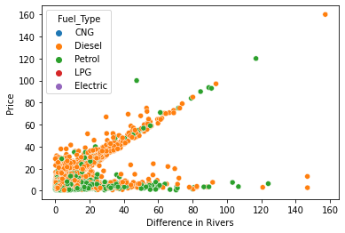

```python
sns.scatterplot(
    data = original_df,
    x="Difference in Rivers",
    y = "Price",
    hue=original_df["Fuel_Type"],
)
```

OBSERVATIONS ABOVE:

Our model predicts that resale value of diesel cars is higher compared to petrol cars.